# Biased regression

Methods for Regression and classification

Katia Meziani

### Package

```r
library(scatterplot3d) # plot3D
library(pls)
library(glmnet)
```

# Generalities

#### 1.Notations

**Notations**

**Gram matrix.**
$$G_n = \frac{X^TX}{n} = \frac{1}{n} \sum_{i=1}^n{x_{i,j}}^2$$

**Some norms.** For all $u \in R^p$ and $J_0 \subseteq \{1,...,p\}$, we denote by

- $\Vert u \Vert_n^2 = \frac{1}{n}\sum_{i=1}^p u_i^2$
- $\Vert u \Vert_1 = \sum_{j=1}^p |u_j|$
- $\Vert u \Vert_{u,{J_0}}= \sqrt {\sum_{j \in J_0 } {u_j}^2}$
- $\Vert u \Vert_{u,{J_0}} = \sum_{j \in J_0 } \vert u_j \vert$

**The subdifferential** of the $\ell_1$ norm of a vector at point $u\in\mathbb{R}^p$ is the vectorwith components
$$\begin{eqnarray}
\tag{Subdifferential}
\label{subdifferential}
u_j =\partial(| \cdot |)(u_j) = \left\{
\begin{array}{ll} \text{sign}(u_j), &\text{if}\quad u_j \neq 0
\\[0pt] \nu_j\in[-1,1], &\text{if}\quad u_j = 0 \end{array} \right.
\end{eqnarray}$$

#### 2. Linear gaussian regression setting

Fix $p \geq 2$ and $n\geq 1$ and consider the $n$-sample $\left\{(x_i,y_i)\in\mathbb{R}^p\times\mathbb{R}\right\}_{i=1}^n$ such that $\forall i\in\llbracket 1,n\rrbracket$ and $\beta^* \in \mathbb{R}^p$

$$\begin{equation*}
\label{reg}
y_i = x_i^\top\beta^* + \epsilon_i,\quad
\epsilon_i\overset{iid}{\sim}\mathscr{N}(0,\sigma^2).
\end{equation*}$$

**Matrix form.** For $j\in\llbracket 1,p\rrbracket$, $X_j\in\mathbb{R}^n$, we denote by $X=[X_1|\cdots|X_p]$, then the previous model can be written as
$$\begin{equation}
\tag{Mod}
\label{Mod}
Y = \sum_{j=1}^p\beta_j^*X_j + \epsilon= X\beta^* + \epsilon, \quad
\epsilon\sim\mathscr{N}(\boldsymbol{0}_n,\sigma^2\mathbf{I}_n).
\end{equation}$$

#### 3. Motivations

**Statistical Learning** Given a training sample $\big\{(x_i,Y_i)\big\}_{i=1}^n$, we want to predict futur value of $Y$.

1. Set a family of model ${\large{\mathscr{F}}}$.
   $$\text{Here,
   }\quad{\large{\mathscr{F}}}=\{x^\top\beta,\beta\in\mathbb{R}^p\}$$
2. Pick $\widehat f\in{\large{\mathscr{F}}}$ based on the training set
   $$\text{Here, }\quad\widehat f(x)=\widehat
   y=x^\top\widehat\beta,\quad\text{where}\quad\widehat\beta=(X^\top
   X)^{-1}X^\top Y$$
3. Asses the accuracy of the model $\widehat f$ on the new observations (*Test* sample).

**[Recall: Generalization property]**

A good model should predict futur value correctly
$$R(\widehat f)=\text{E}\|Y-\widehat f(X)\|^2=\sigma^2+bias^2(\widehat f)+
\text{Tr}(\text{Var}(\widehat f))$$

The risk is **not directly computable** since the law $(X,Y)$ is unknown. Here

$$R(\widehat f)=\text{E}\|Y-\widehat
f(X)\|^2=\sigma^2+bias^2(\widehat f)+ \sigma^2p$$

**[Empirical risk]**

For $\widehat f$, we can estimate $R(\widehat f)$ from a *Test* sample $\big\{(x_t,Y_t)\big\}_{t=1}^T$

$$\text{Here, }\quad \widehat R(\widehat
f)=\frac 1T\sum_{t=1}^T\left(Y_t-\widehat f(x_t)\right)^2$$

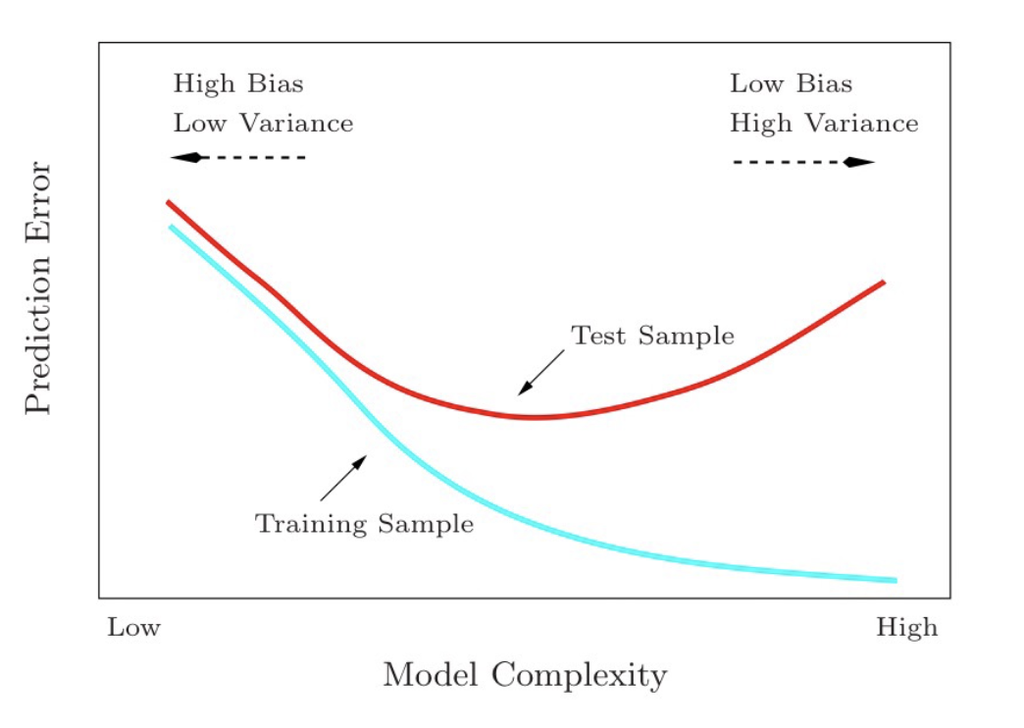

[Bias/Variance compromise]

Consider the regression linear model is correct. Then, Gauss-Markov theorem guarantee that the OLSE is the best linear unbiased estimator. We have seen that it make sense to use a low variance biased estimator

📌 First strategy : **Model selection.** Step by step methods look for a small number of active predictors $s.t.$ $Y\approx X_s\beta_s$.

- **Advantages.** Better interpretability, improve prediction performance.
- **Disadvantages.** Greedy algorithm, may provide a suboptimal model for correlated predictors, Backward selection does not work if $n<p$.

📌 Second strategy : **Regularization.** For correlated predictors, the OLSE of $\beta_j$ may have large variance (and thus take large values). To control the variance of estimators, we can impose constraints on the size of estimators. This may produce an estimator with improved prediction accuracy.
$$\widehat\beta_\lambda \in \mathrm{argmin}_{\beta\in \mathbb{R}^{p}}\| Y
- X \beta\|_n^2 + \lambda\,\mathrm{pen}(\beta),$$
where $\lambda>0$ is a regularization parameter.

**[Objectives]**

- **Numerical stability.** Bad conditionning of $X^\top X$ for correlated predictors $(X_1,\dots,X_p)$.
- **Improve prediction accuracy.** Increase bias to decrease variance. Bound/control the impact of nonactive predictors. Improve interpretability. Control model complexity.
- **Variable selection.**

# 1. Ridge regression

## 1.1. Definition

**[Ridge estimator]**

Let $\lambda>0$, then the Ridge estimator ([*Hoerl and Kennard, 1970*]) is such that
$$\widehat\beta^R(\lambda)=\arg\min_{\beta\in\mathbb{R}^{p}}\|Y-X\beta\|_n^2+\lambda\|\beta\|^2$$
The parameter $\lambda$ is called the **tuning/regularization parameter**.

📝 **Intercept Parameter.** The intercept parameter is not penalized in Ridge regression, allowing it to freely adjust to the data.  
📝 **Improved Numerical Stability.** Ridge regression enhances numerical stability, particularly in situations with multicollinearity among predictors, which can lead to inflated variances.  
📝 **Better Prediction Accuracy.** By shrinking the coefficients of correlated predictors, Ridge regression can achieve better prediction accuracy, especially when the model is complex.  
📝 **Unique Solution.** The strongly convex nature of the Ridge functional ensures that there is a unique solution to the optimization problem, making it robust against overfitting.  
📝 **Closed Form Solution.** Ridge regression offers a closed-form solution, enabling fast computations during the model fitting process.

**[Proposition 1]**

Let $\lambda>0$, then the Ridge estimator ([*Hoerl and Kennard, 1970*]) is such that
$$\widehat\beta^R(\lambda)=(X^TX+\lambda
\mathbf{I}_p)^{-1}X^TY.$$
The parameter $\lambda$ is called the **tuning/regularization parameter**.

📝 If $\lambda>0$, then $(X^TX+\lambda \mathbf{I}_p)^{-1}$ is well defined.
📝 Let consider the conditions of existance of $\widehat\beta$ the ordinary least squares estimator (OLSE), then
$$\widehat\beta^R(\lambda)=(X^TX+\lambda
\mathbf{I}_p)^{-1}X^TX\widehat\beta.$$

**Illustration in dimension 2.**

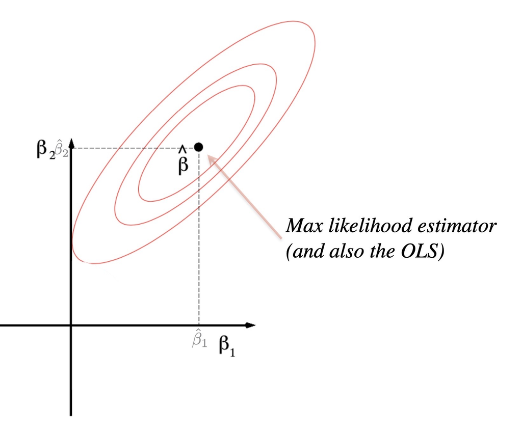

[*OLS estimator*]

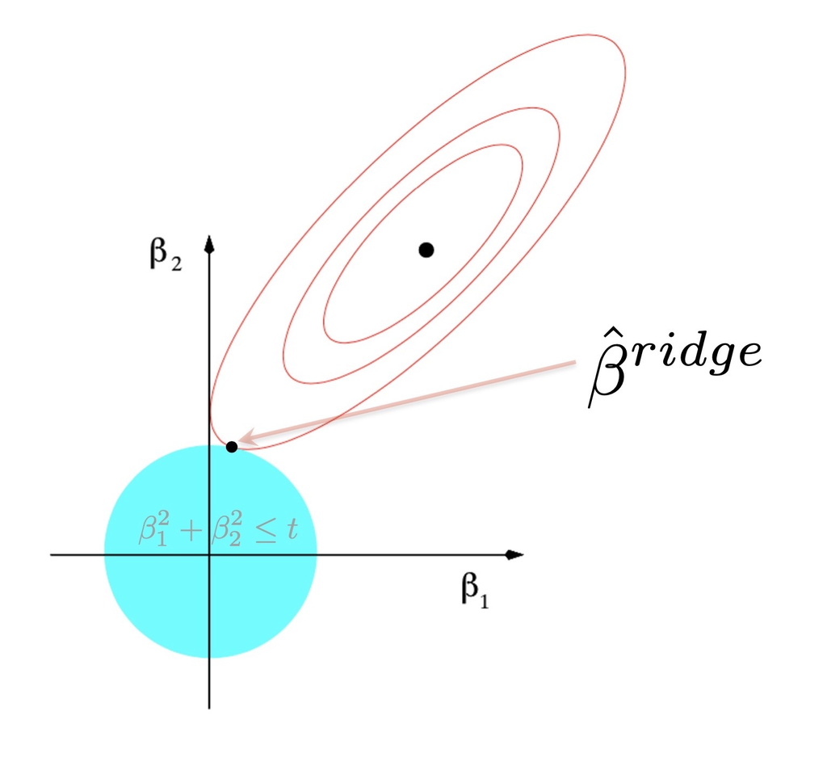

[*Ridge estimator*]

In **classical setting**, we want to maximize the likelihood, which is equivalent to minimizing
$$\sum_{i=1}^n(y_i-\beta_1-\beta_2x_i)^2$$
In **Ridge regression setting**, we minimize
$$\sum_{i=1}^n(y_i-\beta_1-\beta_2x_i)^2+\lambda(\beta_1^2+\beta_2^2)$$
**Equivalent to placing a restriction** $\beta_1^2+\beta_2^2\leq t$ in the maximisation of the likelihood

## 1.2. Main theorem

Let denote $\Lambda_j\geq 0$ eigenvalues of $X^\top X$. As $\lambda>0$, the eigenvalues of $(X^\top X+\lambda \mathbf{I}_p)^{-1}$ are $(\Lambda_j+\lambda)^{-1}> 0$

**[Theorem 1]** Let $\lambda>0$, then

1. $\text{E}[\widehat\beta^R(\lambda)]=\beta-\lambda(X^TX+\lambda \mathbf{I}_p)^{-1}\beta$
2. $\text{Var}[\widehat\beta^R(\lambda)]=\sigma^2(X^TX+\lambda \mathbf{I}_p)^{-1}X^TX(X^TX+\lambda \mathbf{I}_p)^{-1}$
3. Let $X^TX=P \rm{Diag}(\Lambda)P^T$, where $P$ is a matrix such that $P^T=P^{-1}$ and $\|P^T\beta\|^2=\|\beta\|^2$, then the mean square error (MSE) is equal to
   $$\text{E}\|\widehat\beta^R(\lambda)-\beta\|^2_2=\sum_{j=1}^p\frac{\sigma^2\Lambda_j+\lambda^2[P^T\beta]^2_j}{(\lambda+\Lambda_j)^2}$$

*Proof of 1.* $\quad$ Let $\widehat\beta^R(\lambda)=(X^TX+\lambda \mathbf{I}_p)^{-1}X^TX\widehat\beta,$ where $\widehat\beta$ is such that
$$\text{E}[\widehat\beta]=\beta\quad\text{and}\quad\text{Var}[\widehat\beta]=\sigma^2(X^TX)^{-1}$$
Then,
$$\begin{eqnarray*}
\text{E}[\widehat\beta^R(\lambda)]&=&(X^TX+\lambda
\mathbf{I}_p)^{-1}X^TX\text{E}[\widehat\beta]
=(X^TX+\lambda \mathbf{I}_p)^{-1}X^TX\beta\\
&=&(X^TX+\lambda \mathbf{I}_p)^{-1} (X^TX
\color{red}{+\lambda\mathbf{I}_p-\lambda\mathbf{I}_p} )\beta\\
&=&(X^TX+\lambda \mathbf{I}_p)^{-1}(X^TX
+\lambda\mathbf{I}_p)\beta-\lambda (X^TX+\lambda
\mathbf{I}_p)^{-1}\beta\\
&=&\beta-\lambda (X^TX+\lambda \mathbf{I}_p)^{-1}\beta\square
\end{eqnarray*}$$

*Proof of 2.* $\quad$ As $\text{Var}[\widehat\beta]=\sigma^2(X^TX)^{-1}$, it comes

$$\begin{eqnarray*}
\text{Var}[\widehat\beta^R(\lambda)]&=&(X^TX+\lambda
\mathbf{I}_p)^{-1}X^TX\text{Var}[\widehat\beta]X^TX(X^TX+\lambda
\mathbf{I}_p)^{-1}\\
&=&\sigma^2(X^TX+\lambda
\mathbf{I}_p)^{-1}X^TX(X^TX)^{-1}X^TX(X^TX+\lambda \mathbf{I}_p)^{-1}\\
&=&\sigma^2(X^TX+\lambda \mathbf{I}_p)^{-1}X^TX(X^TX+\lambda
\mathbf{I}_p)^{-1}\square
\end{eqnarray*}$$

*Proof of 3.* $\quad$ First recall that for any estimator $\widehat\theta$ of an parameter $\theta\in\mathbb{R}^p$
$$\begin{eqnarray}
\label{dbv}
H(\widehat\theta)=\text{E}\left[(\theta-\widehat\theta)(\theta-\widehat\theta)^T\right]=\left(\theta-\text{E}[\widehat\theta]\right)\left(\theta-\text{E}[\widehat\theta]\right)^T+
\text{Var}[\widehat\theta].
\end{eqnarray}$$
Applying it to $\widehat\beta^R(\lambda)$, we get
$$\begin{eqnarray*}
H(\widehat\beta^R)=\left(\beta-\text{E}[\widehat\beta^R(\lambda)]\right)\left(\beta-\text{E}[\widehat\beta^R(\lambda)]\right)^T+
\text{Var}[\widehat\beta^R(\lambda)].
\end{eqnarray*}$$

Moreover,
$$\begin{eqnarray}
H(\widehat\beta^R)&=&\left(\lambda (X^TX+\lambda
\mathbf{I}_p)^{-1}\beta\right)\left(\lambda (X^TX+\lambda
\mathbf{I}_p)^{-1}\beta\right)^T+
\text{Var}[\widehat\beta^R(\lambda)]\nonumber\\
&=&\lambda^2(X^TX+\lambda
\mathbf{I}_p)^{-1}\beta\beta^T(X^TX+\lambda
\mathbf{I}_p)^{-1}+\sigma^2(X^TX+\lambda
\mathbf{I}_p)^{-1}X^TX(X^TX+\lambda \mathbf{I}_p)^{-1}\nonumber\\
\tag{1}
\label{propo2d}
&=&(X^TX+\lambda
\mathbf{I}_p)^{-1}\left(\lambda^2\beta\beta^T+\sigma^2X^TX\right)(X^TX+\lambda
\mathbf{I}_p)^{-1}
\end{eqnarray}$$

From now, we denote by $\text{diag}(\Lambda)$ and $\text{diag}\left(1/(\Lambda+\lambda)\right)$ the $p\times p$ diagonal matrices whose diagonal elements are the respectively $1/(\Lambda_i+\lambda)$ and $\Lambda_i+\lambda$, with $\Lambda_i$ the eigenvalues of the matrix $X^TX$. Then, let us decompose $X^TX=P\text{diag}(\Lambda)P^T$, it comes
$$X^TX=P\text{diag}(\Lambda)P^T\quad\text{and}\quad(X^TX+\lambda
\mathbf{I}_p)^{-1}=P\text{diag}\left(1/(\Lambda+\lambda)\right)P^T$$

Then, as $P^TP=PP^T=\mathbf{I}_p$ and by using equation $\eqref{propo2d}$ becomes
$$\begin{eqnarray}
H(\widehat\beta^R)&=&(X^TX+\lambda
\mathbf{I}_p)^{-1}\left(\lambda^2\beta\beta^T+\sigma^2X^TX\right)(X^TX+\lambda
\mathbf{I}_p)^{-1}\nonumber\\
&=&\color{red}{P\text{diag}\left(1/(\Lambda+\lambda)\right)P^T}\left(\lambda^2\beta\beta^T+\sigma^2\color{blue}{P\text{diag}(\Lambda)P^T}\right)\color{red}{P\text{diag}\left(1/(\Lambda+\lambda)\right)P^T}\nonumber\\
&=&\color{red}{P\text{diag}\left(1/(\Lambda+\lambda)\right)}
\left(\lambda^2\color{red}{P^T}\beta\beta^T\color{red}{P}
+\sigma^2\color{red}{P^T}\color{blue}{P\text{diag}(\Lambda)P}
\color{red}{P^T}\right)
\color{red}{\text{diag}\left(1/(\Lambda+\lambda)\right)P^T}\nonumber\\
\tag{2}
\label{propo3d}
&=&P\text{diag}\left(1/(\Lambda+\lambda)\right)
\left(\lambda^2P^T\beta\beta^TP
+\sigma^2\text{diag}(\Lambda)\right)
\text{diag}\left(1/(\Lambda+\lambda)\right)P^T
\end{eqnarray}$$

We are now ready to prove 3. of the theorem
$$\begin{eqnarray*}
\text{E}\left[\|\widehat\beta^R(\lambda)-\beta\|^2_2\right]&&=\text{E}\left[\text{Tr}\left(\|\widehat\beta^R(\lambda)-\beta\|^2_2
\right)\right]=\text{E}\left[\text{Tr}\left((\beta-\widehat\beta^R(\lambda))^T(\beta-\widehat\beta^R(\lambda))\right)\right]\\
&&=\text{E}\left[\text{Tr}\left((\beta-\widehat\beta^R(\lambda))(\beta-\widehat\beta^R(\lambda))\right)^T\right]\\
&&=\text{Tr}\left[\text{E}\left((\beta-\widehat\beta^R(\lambda))(\beta-\widehat\beta^R(\lambda))\right)^T\right]=\text{Tr}(H(\widehat\beta^R))
\end{eqnarray*}$$

By using ($\ref{propo3d}$), we have as $P^TP=\mathbf{I}_p$
$$\begin{eqnarray*}
\text{E}\left[\|\widehat\beta^R(\lambda)-\beta\|^2_2\right]&=&\text{Tr}\left[\text{E}\left((\beta-\widehat\beta^R(\lambda))(\beta-\widehat\beta^R(\lambda))\right)^T\right]\\
&=&\text{Tr}\left[P\text{diag}\left(1/(\Lambda+\lambda)\right)
\left(\lambda^2P^T\beta\beta^TP
+\sigma^2\text{diag}(\Lambda)\right)
\text{diag}\left(1/(\Lambda+\lambda)\right)P^T \right]\\
&=&\text{Tr}\left[P^TP\text{diag}\left(1/(\Lambda+\lambda)\right)
\left(\lambda^2P^T\beta\beta^TP
+\sigma^2\text{diag}(\Lambda)\right)
\text{diag}\left(1/(\Lambda+\lambda)\right) \right]\\
&=&\text{Tr}\left[\text{diag}\left(1/(\Lambda+\lambda)\right)
\left(\lambda^2P^T\beta\beta^TP
+\sigma^2\text{diag}(\Lambda)\right)
\text{diag}\left(1/(\Lambda+\lambda)\right) \right]\\
&=&\text{Tr}\left[\text{diag}\left(1/(\Lambda+\lambda)^2\right)
\left(\lambda^2P^T\beta\beta^TP
+\sigma^2\text{diag}(\Lambda)\right)\right]\\
&=&\text{Tr}\left[\text{diag}\left(1/(\Lambda+\lambda)^2\right)
\left(\lambda^2P^T\beta\beta^TP\right)\right]
+
\text{Tr}\left[\text{diag}\left(1/(\Lambda+\lambda)^2\right)
\left(\sigma^2\text{diag}(\Lambda)\right)\right]\\
&=&\text{Tr}\left[\text{diag}\left(\lambda^2/(\Lambda+\lambda)^2\right)
\left(P^T\beta\beta^TP\right)\right]+
\text{Tr}\left[\text{diag}\left(\sigma^2\Lambda/(\Lambda+\lambda)^2\right)\right]\\
&=&\sum_{j=1}^p\frac{\lambda^2[P^T\beta]_j^2}{(\Lambda_j+\lambda)^2}+\sum_{j=1}^p\frac{\sigma^2\Lambda_j}{(\Lambda_j+\lambda)^2}=\sum_{j=1}^p\frac{\lambda^2[P^T\beta]_j^2+\sigma^2\Lambda_j}{(\Lambda_j+\lambda)^2}\square
\end{eqnarray*}$$

📝 The Ridge estimator $\widehat\beta^R(\lambda)$ is **biased**.
📝 However, it may provide better performance from the Mean Squared Error (MSE) perspective. Specifically, as $\lambda$ increases, the variance of the Ridge estimator decreases.
📝 If $\lambda\rightarrow +\infty$ (resulting in large bias and null variance), then $\widehat\beta^R(\lambda)\rightarrow 0$ $\Rightarrow$ **no regressors are selected**, leading to:
$$\text{E}\|\widehat\beta^R(\lambda) - \beta\|^2_2 \rightarrow
\|\beta\|^2.$$

📝 Conversely, if $\lambda\rightarrow 0$ (resulting in small bias and large variance), then $\widehat\beta^R(\lambda)\rightarrow \widehat\beta$ $\Rightarrow$ **all regressors are selected**, leading to:
$$\text{E}\|\widehat\beta^R(\lambda) - \beta\|^2_2 \rightarrow \sigma^2 \,
\text{Tr}((X^TX)^{-1}).$$

📝 If $X^TX=\mathbf{I}_p$ (**orthogonal matrix** $X$) then
$$\widehat\beta^R(\lambda)=\frac{X^TY}{1+\lambda}=\frac{\widehat\beta}{1+\lambda}.$$
The values of $\widehat\beta_k$ from the Ordinary Least Squares Estimator (OLSE) decrease as $\lambda$ increases. The **Ridge estimator is classified as a “*shrinkage estimator*”**; it shrinks the coefficients while retaining all variables.
📝 Ridge regression is particularly beneficial when the eigenvalues $\Lambda_j$ are small.
📝 Finding a suitable compromise requires **proper tuning** of $\lambda$., and it must be calibrated appropriately!

## 1.3. Toy example

In this section, we will explore a linear Gaussian regression model with two highly correlated explanatory variables, $X_1$ and $X_2$. Consider the following linear regression model where the explanatory variables $X_1$ and $X_2$ are **strongly correlated**

$$Y = X_1 \beta_1 + X_2\beta_2 + \epsilon,\quad
\epsilon\sim\mathscr{N}(\boldsymbol{0}_n)$$

**Ⓡ** To construct this model with a high correlation of approximately 0.9, we use the following code:

```r
set.seed(2024)
x1 <- rnorm(100)
x2 <- x1 + rnorm(100,0, 0.5)
mcor<-cor(x1,x2)
cat("Correlation=",mcor)
```

```
## Correlation= 0.9000157
```

**Ⓡ** Next, we simulate the data for the above model and visualize the 3D scatterplot using `scatterplot3d` of the package `scatterplot3d`.

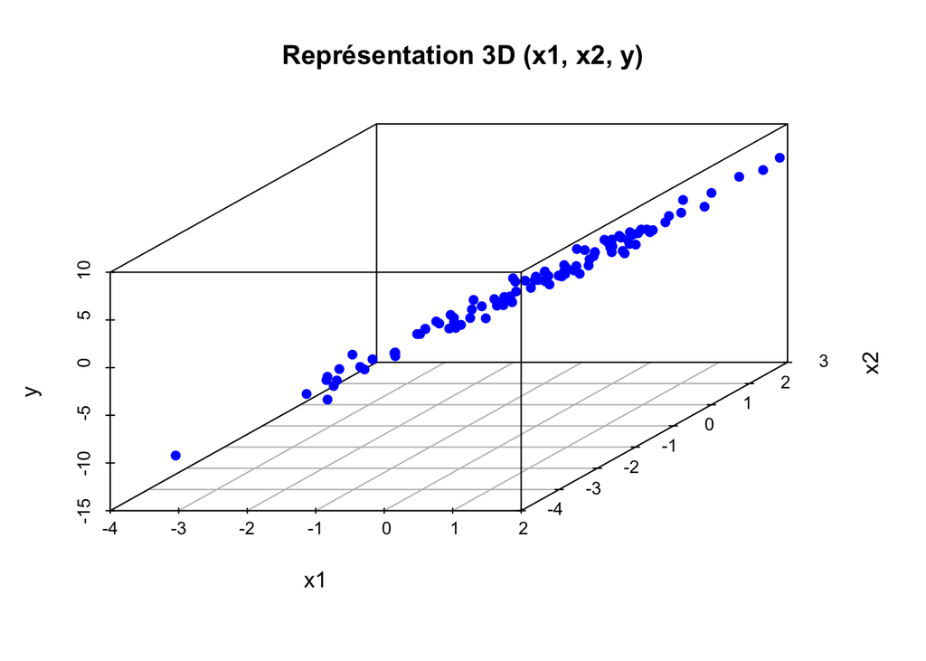

```r
library(scatterplot3d)
set.seed(2024)
y <- x1 + x2 +rnorm(100)
scatterplot3d(x1, x2, y, pch = 16, color = "blue", main = "Représentation 3D (x1, x2, y)",
              xlab = "x1", ylab = "x2", zlab = "y")
```

📈 As $X_1 \approx X_2$, this implies that the two variables are nearly identical, indicating they are strongly collinear or correlated. The original model: $Y = X_1 \beta_1 + X_2 \beta_2 + \epsilon$ can be approximated as:
$$Y \approx X \beta_1 + X \beta_2 + \epsilon\approx X (\beta_1 + \beta_2)
+ \epsilon\approx X \beta + \epsilon,$$
where $\beta = \beta_1 + \beta_2$. Then, $Y$ is approximately a linear function of $X$, simplifying the model to a linear regression of the form: $Y \approx X \beta + \epsilon$.
Moreover, if $X_1\approx X_2$, we have several almost equivalent representations of $Y$ as for all $\gamma\geq 0$. The Ordinary Least Squares Estimator (OLSE) provides the same prediction $\widehat Y$ but with coefficients $\widehat\beta_j$,indexed by $\gamma$, that exhibit high variance.
$$Y \approx X_1 (\beta_1 + \gamma) + X_2 (\beta_2 - \gamma) +
\epsilon.$$

📌 A constraint on the norm of $\beta$ allows us to select one representation with a small $l_2$-norm, which is given by:
$$(\beta_1 + \gamma)^2 + (\beta_2 - \gamma)^2$$
This expression is minimized for $\gamma = (\beta_2-\beta_1)/2$. In this case, we find that:
$$\beta_j = (\beta_1 +
\beta_2)/2$$

This implies that the Ridge estimator tends to average the coefficients corresponding to correlated predictors.The averaging process reduces the variability of the coefficients, pulling them closer together and towards zero. This **shrinkage** helps mitigate the impact of multicollinearity, leading to more stable and reliable estimates.

## 1.4. Different Libraries

**1. Function `lm.ridge` from the `MASS` package**

- This function is used to perform Ridge regression.

```r
library(MASS)
model <- lm.ridge(y.train ~ x.train, data = your_data_train)
```

- *Standardization*: **By default**, `lm.ridge` **does not standardize** the regressors or the response variable. If you want to standardize your data before fitting the model, you must do this manually:

```r
your_data_train_scaled <- scale(your_data_train)
model <- lm.ridge(y.train ~ x.train, data = your_data_train_scaled)
```

**2. Function `train(, method='glmnet', alpha=0)` from the `caret` package**

- This function is part of the `caret` package and is used for training models, including Ridge regression.

```r
library(caret)
model <- train(y.train ~ x.train, data = your_data_train, method = 'glmnet', alpha = 0)
```

```r
model <- train(x.train, y.train, method = 'glmnet', method = 'glmnet', alpha = 0, preProcess = c("center", "scale"))
```

The **response variable** needs to be standardized separately before fitting the model. If the response variable is standardized, the output coefficients will be reported in the standardized scale. If no standardization is applied, the coefficients are reported in the original scale.

```r
y.train_scaled <- scale(y.train)
model <- train(x.train, y.train_scaled, method = 'glmnet', method = 'glmnet', alpha = 0, preProcess = c("center", "scale"))
```

**3. Function `glmnet()` from the `glmnet` package**

- This function is utilized for Ridge regression when `alpha=0` and can be called as follows:

```r
library(glmnet)
model <- glmnet(x.train, y.train, standardize=TRUE, alpha=0, lambda=lambda_try)
```

- *Standardization of the regressors* are **done by default**. If you wish to prevent standardization, you can set `standardize=FALSE`.
- *Standardization of the response Variable*: The response variable is **not automatically standardized or centered**. If you want it standardized, you need to do this manually before passing it to the `glmnet` function:

```r
y.train_scaled <- scale(y.train)
model <- glmnet(x.train, y.train_scaled, standardize=TRUE, alpha=0, lambda=lambda_try)
```

**Ⓡ** **Back to our toy examples.**

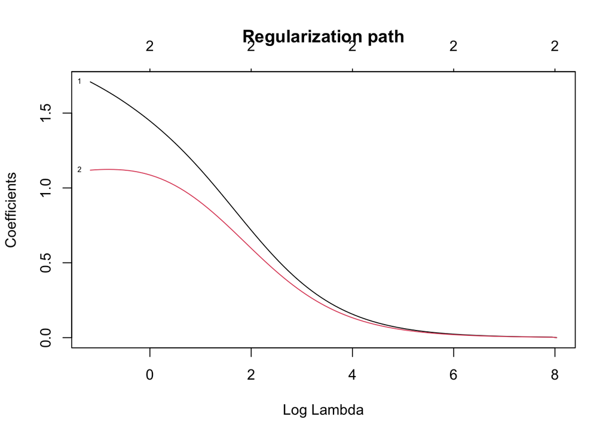

```r
library(glmnet)
x=cbind(x1,x2)
fit.ridge=glmnet(x,y,alpha=0)
plot(fit.ridge,xvar="lambda",label=TRUE,main='Regularization path')
```

📈 Despite this shrinkage, all variables remain in the model, allowing for their contributions to be retained in the analysis while controlling for their correlations. In summary, the Ridge estimator not only provides a way to manage the variance of the estimated coefficients but also ensures that all predictors are included in the final model, facilitating interpretation and inference.

# 2. LASSO regression

Ridge regression may be particularly useful when there is a lot of variability in the OLS estimates (e.g. if there is high collinearity). However, there is **no variable selection** in this procedure, as the $\ell_2$ regularization do not allows some estimates to be exactly 0! Ridge performs shrinkage but does not provide sparse solution.

## 2.1. General definition

**Second strategy of regularization.** It is possible to design a penalty function that can enforce sparsity on $\widehat\beta$.

**Illustration in dimension 2.**

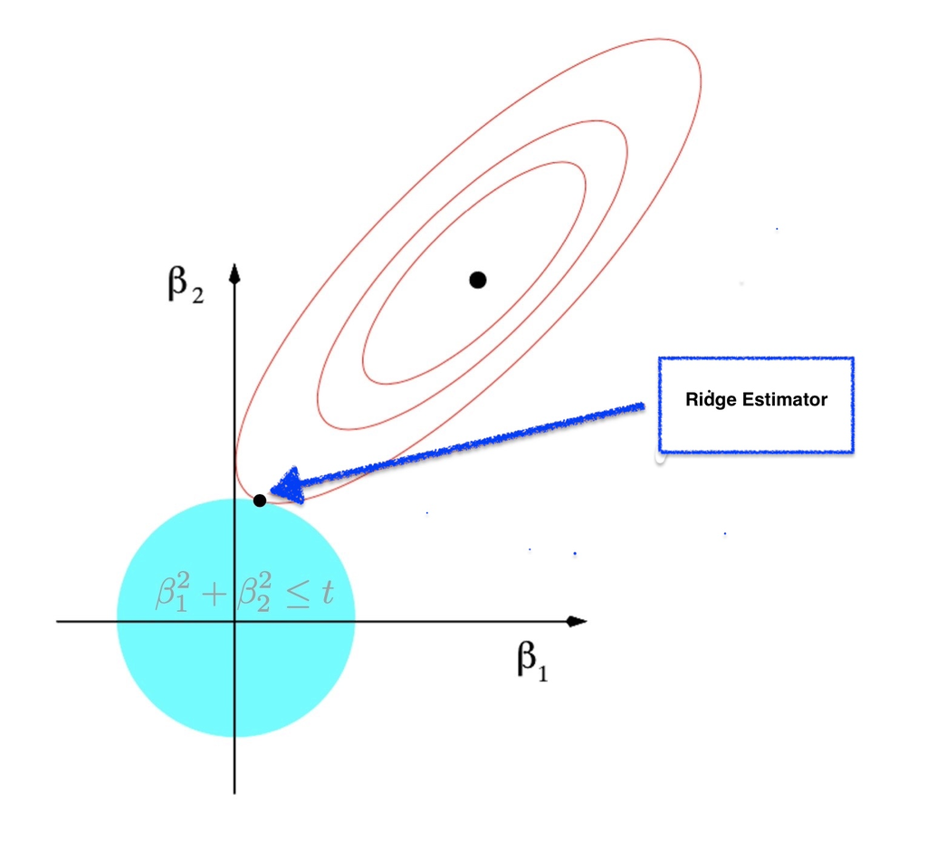

[*Ridge estimator*]

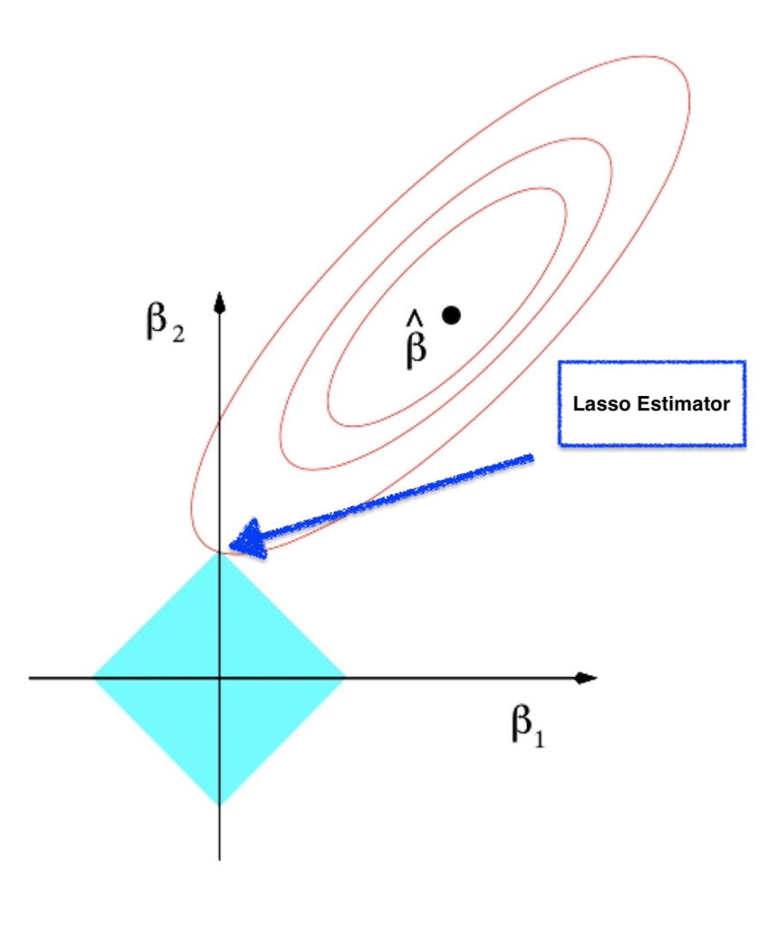

[*LASSO estimator*]

It corresponds to the penalization
$$\sum_{i=1}^n(y_i-\beta_1-\beta_2x_i)^2+\lambda(|\beta_1|+|\beta_2|)$$
**This is called the LASSO (least absolute shrinkage and selection operator)**

**[LASSO estimator]**

Let $\lambda>0$, then the LASSO estimator ([*Tibshirani, 1996*]) is such that
$$\widehat{\beta}^{\lambda,L}:=\widehat{\beta}^{\text{L}}
(\lambda) = \mathrm{argmin}_{\beta\in\mathbb{R}^{p}}
\|Y - X \beta\|_n^2 + \lambda\,\|\beta\|_1,$$
where the regularization parameter $\lambda>0$.

📝 **The intercept is not penalized.** In LASSO regression, the intercept term is excluded from the regularization penalty, allowing it to freely fit the data.  
📝 **Closed form for LASSO estimator.** Generally, there is no closed-form solution for the LASSO estimator, making the optimization process more complex.  
📝 **Convex optimization problem.** LASSO is framed as a convex optimization problem, and there exist efficient algorithms, such as LARS (Least Angle Regression), for approximating solutions.

## 2.2. Orthogonal setting

In the specific case of an orthogonal design matrix $X$, it is possible to derive a closed-form solution for the LASSO estimator.

} Let $\lambda>0$, if $X^\top X=\mathbf{I}_p$ then the LASSO estimator is equal to
$$\widehat\beta^L_j(\lambda)={\rm sign}(X^T_jY)\left[ |
X^T_jY|-\lambda/2\right]_+,$$
where $\left[ x\right]_+=x$ if $x\geq 0$ and $0$ otherwise.

*Proof.* Let as exercice.

📝 **Regularization and variable selection.** LASSO not only regularizes the model but also performs variable selection by shrinking some coefficients to zero, effectively retaining a subset of predictors.

📝 **Regressor excluded.** For any $j\in\llbracket 1,p\rrbracket$, the quantity $|X^\top_jY|$ serves as an indicator of the correlation between the regressor $X_j$ and the response $Y$. Specifically, if $\lambda/2> | X^\top_jY|$ then $\widehat\beta^L_j(\lambda)=0$, which means the regressor $X_j$ is excluded from the model. Consequently, if
$$\lambda/2> \| X^\top Y\|_\infty=\max_j|
X^\top_jY|\Rightarrow\widehat\beta^L(\lambda)=0,$$
there exists an infinite number of $\lambda$ values such that $\widehat\beta^L(\lambda)=0$.

📝 **Regressor retained.** Let $k\in\llbracket 1,p\rrbracket$
$$\| X^\top Y\|_\infty=\max_j| X^\top_jY|=| X^\top_kY|,$$
which indicates that the regressor $X_k$ is the most correlated to $Y$. So as soon as $\lambda/2$falls below the threshold $\| X^\top Y\|_\infty$, the first explanatory variable retained in the model will be the regressor$X_k$.

📝 **Choice of $\lambda$**

- As $\lambda\to 0$ the model exhibits small bias but large variance (similar to Ordinary Least Squares Estimation, LSE).
- As $\lambda\to \infty$ the model results in large bias and effectively null variance.  
  $\Rightarrow$ Finding an optimal balance necessitates careful tuning of$\lambda$.

📝 The **Ridge estimator** helps prevent overfitting. However, it does not perform variable selection; instead, it shrinks the $\beta$ coefficients while retaining all regressors in the model. The **LASSO estimator** also shrinks coefficients, but it can set some coefficients to zero, thereby performing variable selection. This leads to a sparse solution, enhancing interpretability.

## 2.3. Main results

This part is based on the paper of [Bickel *et al*].

### 2.3.1. Assumptions

**[Sparsity set]** For all $\beta \in \mathbb{R}^p$, we denote by $J(\beta)\subseteq\{1,\cdots,p\}$ the **sparsity set**, where the vector $\beta$ has non-zero coordinates
$$\begin{eqnarray*}
\label{eq:sparsity_set}
J(\beta)& =& \{j :\ \beta_j \neq0 \}
\end{eqnarray*}$$

**[Sparsity of $\beta$]** The **sparsity of the vector** $\beta$ is characterized by the value $M(\beta)$, the cardinality of $J(\beta)$:
$$\begin{eqnarray*}
\label{eq:indiceS}
M(\beta)&=&\sum_{j=1}^p\mathbb{1}_{\beta_j\neq0}=\vert J(\beta)
\vert
\end{eqnarray*}$$

**[Assumptions $\mathscr{H}$]** We assume in this lecture:

- The Gram matrix $G_n$ is such that its diagonal elements are equal to 1.
- The sparsity index is such that $M(\beta^*)\leq s$ for $1\leq s\leq p$.

From now, we define the LASSO estimator as follows
$$\widehat{\beta}^{\lambda,L}= \arg\min_{\substack{\beta \in
\mathbb{R}^p}}\bigg\{ {\Vert Y - X\beta\Vert_n}^2 + 2\lambda {\Vert
\beta \Vert}_1 \bigg\}$$
where the regularization parameter $\lambda>0$.

**DISCUSSION.**

Our primary focus is on the scenario where **$p>n$** and even **$p>>n$**. In this case, the Gram matrix $G_n$ becomes degenerate, which can be expressed as:
$$\min_{\substack{ \delta \in\mathbb{R}^p \\ \delta \neq
0} } \frac{(\delta^\top G_n\delta)^{1/2}}{\sqrt{n} \Vert \delta
\Vert_{2}}\equiv \min_{\substack{ \delta \in\mathbb{R}^p \\ \delta \neq
0} } \frac{\Vert X\delta \Vert_2}{\sqrt{n} \Vert \delta
\Vert_{2}}=0$$
In this context, Ordinary Least Squares Estimation (OLSE) is ineffective since it necessitates the positive definiteness of $G_n$, which implies:
$$\min_{\substack{ \delta \in\mathbb{R}^p \\ \delta \neq
0} } \frac{\Vert X\delta \Vert_2}{\sqrt{n} \Vert \delta
\Vert_{2}}>0.$$

Conversely, the LASSO method operates under much weaker assumptions. It accomplishes this by:

- Replacing the minimization over all vectors with minimization over a restricted set of vectors.
- Substituting the $\ell_2$-norm of the entire vector $\delta$ with the $\ell_2$-norm of only a subset of its components.

For $J_0 = J (\beta^* )$, one notable property of the LASSO is that the residuals $\delta=\widehat{\beta}^{\lambda,L}-\beta^*$ satisfy, with high probability:
$$\Vert \delta\Vert_{1,J_0^c}\leq 3 \Vert \delta\Vert_{1,J_0}.$$

**[Restricted Eigenvalues ($\text{RE}$) assumption: ]**

For an integer $s$ such that $1\leq s \leq p$ and a positive number $c_0$, we assume that the following condition is satisfied:
$$\kappa(s,c_0) := \min_{ \substack{ J_0 \subseteq \{1,...,p\} \\ \vert
J_0 \vert \leq s }}
\ \min_{\substack{ \delta \neq 0 \\ \Vert \delta \Vert_{1,{J_0}^c} \leq
c_0 \Vert \delta \Vert_{1,{J_0}} } } \frac{\Vert X\delta
\Vert_2}{\sqrt{n} \Vert \delta \Vert_{2,J_0}} > 0.$$

### 2.3.2. [Bickel *et al*]’s Theorem

The following theorem, due to [Bickel *et al*], provides rigorous bounds on the prediction error, estimation error, and the support size of the LASSO estimator under the assumptions of model $\eqref{Mod}$, along with the $\mathscr H$ and $\text{RE}(s,3)$ conditions. Specifically, it establishes that for an appropriately chosen regularization parameter $\lambda$, the LASSO estimator achieves high-probability guarantees for these error bounds.

To establish Theorem 2, we require two key lemmas that will help us control the prediction error and establish bounds on the LASSO estimator under certain conditions.

### 2.3.3. Key lemmas

To prove Theorem 2, we first need to establish a key result that bounds the probability of certain events involving the noise term. Specifically, we define the following set, which **captures the concentration of the empirical averages of the noise $\epsilon$**:

**[Lemma 1]**

Let $V_j:=\frac1n\sum_{i=1}^{n} \epsilon_i x_{i,j}=\frac1n X_j^\top\epsilon$, we define the set
$$\Omega = \bigcap_{j=1}^p \left\{ 2 \vert V_j
\vert \leq \lambda \right\} =\bigcap_{j=1}^p \left\{ \big\vert \frac1n
X_j^\top\epsilon\big\vert \leq \lambda/2 \right\}$$
Then for $A>2\sqrt 2$ and $\lambda=A\sigma \sqrt{\frac{\log(p)}{n}}$, we have
$$\text{P}( \Omega )> 1- p^{1-
\frac{A^2}{8}},$$

*Proof.* Denote by $\eta_j=\sqrt{n}V_j=\frac{1}{\sqrt{n}}\sum_{i=1}^{n} x_{i,j}\epsilon_i$, then
$$\begin{eqnarray*}
\text{E}(\eta_j)&=&\frac{1}{\sqrt{n}}\sum_{i=1}^{n}
x_{i,j}\text{E}(\epsilon_i)=0\\
\text{Var}(\eta_j)&=&\frac1n\sum_{i=1}^{n}
x_{i,j}^2\text{Var}(\epsilon_i)=\frac{\sigma^2}n\sum_{i=1}^{n}
x_{i,j}^2=\frac{\sigma^2}n X_j^\top X_j=\sigma^2 \quad \text{by
Assumption }\mathscr H
\end{eqnarray*}$$
Then the $\frac{\eta_j}{\sigma}\sim\mathscr{N}(0,1)$ and are identically distibuted then $\frac{\eta_j}{\sigma}=:\frac{\eta}{\sigma}$ and $s.t.$
$$\begin{array}{ll}\text{P}\left(\Omega^c\right)
&=\text{P}\left(\bigcup_{j=1}^p \big\{ 2 \vert V_j \vert >
\lambda\big \}\right)=\text{P}\left(\bigcup_{j=1}^p \big\{ 2
\vert\eta_j \vert > \lambda\sqrt{n}\big
\}\right)\leq\sum_{j=1}^p\text{P}\left( \vert \frac{\eta_j}{\sigma}
\vert > \frac{\lambda\sqrt n}{2\sigma}\right)\\
&\leq p\text{P}\left( \vert \frac{\eta}{\sigma} \vert >
\frac{\lambda\sqrt n}{2\sigma}\right)\leq p e^{-\frac{\lambda^2
n}{8\sigma^2}}=p e^{-A^2\frac{\log(p)}{8}}=p^{1-A^2/8}
\end{array}.\square$$

In order to prove Theorem 2, we also rely on the following lemma, which provides a crucial inequality that bounds both the prediction error and the $\ell_1$ norm of the difference between the LASSO estimator and the true coefficients. This result will allow us to control the behavior of the LASSO under specific assumptions.

**[Lemma 2]**

Let $A>2\sqrt 2$. Consider model $\eqref{Mod}$ and assume that $\mathscr H$ and $\text{RE}(s,3)$ assumptions are satisfy. For $\lambda=A\sigma \sqrt{\frac{\log(p)}{n}}$, the LASSO estimator $\widehat{\beta}^{\lambda,L}$ is such that with probability greater than $1 - p^{1 - \frac{A^2}{8}}$

$$\begin{eqnarray}
\label{lemmeb}
\tag{Lemme 2}
{\Vert X(\widehat{\beta}^{\lambda,L}- \beta^*) \Vert_n}^2 + \lambda
\Vert \widehat{\beta}^{\lambda,L}- \beta^* \Vert_1 \leq {4 \lambda
{\Vert \widehat{\beta}^{\lambda,L}- \beta^* \Vert_{1,J_0}}},
\end{eqnarray}$$
where $J_0=J(\beta^*)$.

*Proof.* **The proof will be given in Section 2.3.6**

**Consequence of the Lemma 2**

$$\begin{eqnarray}
&&0 \leq \Vert X(\widehat{\beta}^{\lambda,L}- \beta^*) \Vert_n^2
\\
&\Leftrightarrow& 0+\color{red}{ \lambda \Vert
\widehat{\beta}^{\lambda,L}- \beta^* \Vert_1} \leq \Vert
X(\widehat{\beta}^{\lambda,L}- \beta^*) \Vert_n^2 +\color{red}{\lambda
\Vert \widehat{\beta}^{\lambda,L}- \beta^* \Vert_1}\\
&\Leftrightarrow&\color{red}{ \lambda \Vert
\widehat{\beta}^{\lambda,L}- \beta^* \Vert_1} \leq \Vert
X(\widehat{\beta}^{\lambda,L}- \beta^*) \Vert_n^2 +{\lambda \Vert
\widehat{\beta}^{\lambda,L}- \beta^*
\Vert_1}\color{red}{\overset{\color{red}{By\, Lem.2}}{\leq}4 \lambda
\Vert \widehat{\beta}^{\lambda,L}- \beta^* \Vert_{1,J_0}}.
\end{eqnarray}$$

Then, with probability greater than $1 - p^{1 - \frac{A^2}{8}}$, $\color{red}{\quad\lambda \Vert \widehat{\beta}^{\lambda,L}- \beta^* \Vert_1 \leq4 \lambda \Vert \widehat{\beta}^{\lambda,L}- \beta^* \Vert_{1,J_0}}$.  
As $\quad\lambda \Vert \widehat{\beta}^{\lambda,L}- \beta^* \Vert_1 =\lambda \Vert \widehat{\beta}^{\lambda,L}- \beta^* \Vert_{1,J_0}+\lambda \Vert \widehat{\beta}^{\lambda,L}- \beta^* \Vert_{1,J_0^C}$, it comes

$$\begin{eqnarray}
&&\lambda \Vert \widehat{\beta}^{\lambda,L}- \beta^*
\Vert_{1,J_0}+\lambda \Vert \widehat{\beta}^{\lambda,L}- \beta^*
\Vert_{1,J_0^C}\leq 4 \lambda \Vert \widehat{\beta}^{\lambda,L}- \beta^*
\Vert_{1,J_0}\\
&\Leftrightarrow&\lambda \Vert \widehat{\beta}^{\lambda,L}-
\beta^* \Vert_{1,J_0^C}\leq 3 \lambda \Vert \widehat{\beta}^{\lambda,L}-
\beta^* \Vert_{1,J_0}
\end{eqnarray}$$

**With probability greater than $1 - p^{1 - \frac{A^2}{8}}$**, we have
$$\begin{eqnarray}
\label{lemmec2}
\tag{Consequence Lemma 2}
\Vert \widehat{\beta}^{\lambda,L}- \beta^* \Vert_{1,J_0^c}
&\leq& 3 \Vert \widehat{\beta}^{\lambda,L}- \beta^*
\Vert_{1,J_0}.
\end{eqnarray}$$

### 2.3.5. Proof of Theorem 2

*A. Proof of the $\ref{prediction}$.*

By Lemma 2, for $\lambda=A\sigma \sqrt{\frac{\log(p)}{n}}$, with $A>2\sqrt 2$, w.h.p.
$$\Vert X(\widehat{\beta}^{\lambda,L}- \beta^*)
\Vert_n^2 + \lambda \Vert \widehat{\beta}^{\lambda,L}- \beta^* \Vert_1
\leq 4 \lambda {\Vert \widehat{\beta}^{\lambda,L}- \beta^*
\Vert_{1,J_0}}$$
By Cauchy Schwarz, and for $M(\beta^*)\leq s$:
$$\begin{eqnarray}
\label{T1}
\tag{T1}
\Vert X(\widehat{\beta}^{\lambda,L}- \beta^*) \Vert_n^2 + \lambda \Vert
\widehat{\beta}^{\lambda,L}- \beta^* \Vert_1 \leq 4\sqrt{s} \lambda
{\Vert \widehat{\beta}^{\lambda,L}- \beta^* \Vert_{2,J_0}}
\end{eqnarray}$$
By $\text{RE}(s,3)$ assumption, for $\delta=\widehat{\beta}^{\lambda,L}-\beta^*$ and $\kappa:=\kappa(s,3)$
$$\begin{eqnarray}
\label{T2}
\tag{T2}
\kappa\Vert \widehat{\beta}^{\lambda,L}-\beta^*
\Vert_{2,J_0}\leq \frac{1}{\sqrt n }\Vert
X(\widehat{\beta}^{\lambda,L}-\beta^*) \Vert_2=\Vert
X(\widehat{\beta}^{\lambda,L}-\beta^*) \Vert_n.
\end{eqnarray}$$
Then using $\eqref{T1}$ and $\eqref{T2}$
$$\begin{eqnarray*}
\Vert X(\widehat{\beta}^{\lambda,L}- \beta^*)
\Vert_n^2&\leq&\Vert X(\widehat{\beta}^{\lambda,L}- \beta^*)
\Vert_n^2 + \lambda \Vert \widehat{\beta}^{\lambda,L}- \beta^* \Vert_1
\leq 4\sqrt{s} \lambda {\Vert \widehat{\beta}^{\lambda,L}- \beta^*
\Vert_{2,J_0}}\\
&\leq&\frac{4\sqrt{s} \lambda }{\kappa }\Vert
X(\widehat{\beta}^{\lambda,L}-\beta^*) \Vert_n.
\end{eqnarray*}$$

We have
$$\Vert X(\widehat{\beta}^{\lambda,L}- \beta^*)
\Vert_n^2\leq\frac{4\sqrt{s} \lambda }{\kappa }\Vert
X(\widehat{\beta}^{\lambda,L}-\beta^*) \Vert_n.$$

By simplifying by $\Vert X(\widehat{\beta}^{\lambda,L}-\beta^*) \Vert_n$ and squaring, we have
$$\begin{eqnarray}
\label{T3}
\tag{T3}
\Vert X(\widehat{\beta}^{\lambda,L}- \beta^*) \Vert_n^2
&\leq&\frac{16s \lambda^2 }{\kappa^2 }
\end{eqnarray}$$
For $\lambda=A\sigma \sqrt{\frac{\log(p)}{n}}$, we get the prediction bound $\eqref{prediction}$$\square$.

*B. Proof of the $\ref{estimation}$.*

Under $\text{RE}(s,3)$, for $\delta=\widehat{\beta}^{\lambda,L}-\beta^*$ and $\kappa:=\kappa(s,3)$,
$$\begin{eqnarray}
\label{T4}
\tag{T4}
\Vert \widehat{\beta}^{\lambda,L}-\beta^* \Vert_{2,J_0}=\frac{1}{\kappa}
\Vert X(\widehat{\beta}^{\lambda,L}-\beta^*)
\Vert_n\overset{By\,\eqref{T3}}{\leq} \frac{4\sqrt{s}\lambda}{\kappa^2}
\end{eqnarray}$$

By $\eqref{lemmec2}$: $\quad\Vert \widehat{\beta}^{\lambda,L}- \beta^* \Vert_{1,J_0^c} \leq 3 \Vert \widehat{\beta}^{\lambda,L}- \beta^* \Vert_{1,J_0}$,
$$\begin{eqnarray*}
\label{B6}
\Vert \widehat{\beta}^{\lambda,L}-\beta^* \Vert_{1}&=&\Vert
\widehat{\beta}^{\lambda,L}-\beta^* \Vert_{1,J_0}+\Vert
\widehat{\beta}^{\lambda,L}-\beta^* \Vert_{1,J_0^c}\leq 4\Vert
\widehat{\beta}^{\lambda,L}-\beta^* \Vert_{1,J_0}\\
&\leq&4\sqrt{s}\Vert \widehat{\beta}^{\lambda,L}-\beta^*
\Vert_{2,J_0}\quad\text{Cauchy Sch. inequ.}
\leq\frac{16s\lambda}{\kappa^2}\quad\text{by eq. \eqref{T4}}
\end{eqnarray*}$$

for $\lambda=A\sigma \sqrt{\frac{\log(p)}{n}}$, we get the estimation bound $\eqref{estimation}$$\square$.

*C. Proof of the $\ref{EstiSupport}$.*

**[KKT Conditions]** Consider $\eqref{Mod}$.Under $\mathscr H$ assumption, any LASSO solution $\widehat\beta^L$ satisfies the following necessary and sufficient condition (KKT)
$$\left\{\begin{array}{ll}
\frac{1}{n}X_j^\top (Y- X \widehat{\beta}^{\lambda,L}) = \lambda \;
\text{sign}(\widehat{\beta}^{\lambda,L}_j) &
\text{if}\quad\widehat{\beta}^{\lambda,L}_j \neq 0\\
\frac{1}{n}\vert X_j^\top (Y- X \widehat{\beta}^{\lambda,L}) \vert \leq
\lambda &\text{if}\quad \widehat{\beta}^{\lambda,L}_j = 0\\
\end{array}\right.$$

*Proof of the KKT conditions.* Recall
$$\widehat{\beta}^{\lambda,L}= \arg\min_{\substack{\beta \in
\mathbb{R}^p}}\bigg\{ {\Vert Y - X\beta\Vert_n}^2 + 2\lambda {\Vert
\beta \Vert}_1 \bigg\}:=\arg\min_{\substack{\beta \in
\mathbb{R}^p}}f(\beta),$$

- We know that the gradient of the first term at point $\beta$ is
  $$-\frac{2}{n}X^\top (Y - X \beta ).$$
- But the LASSO solution is not differentiable at any point where $\beta_j$ is equal to zero. So use the concept of a $\eqref{subdifferential}$

Therefore, any LASSO solution $\widehat\beta^L$ satisfies the following necessary and sufficient condition (KKT)
$$\overrightarrow{0} \in \partial (f)(\widehat\beta^L)
\Leftrightarrow \text{ KKT Conditions}$$

The LASSO estimator $\widehat{\beta}^{\lambda,L}$ satisfies the KKT condition, then it comes
$$\begin{eqnarray}
\label{T6}
\tag{T6}
\left|\frac{1}{n}X_j^\top (Y- X \widehat{\beta}^{\lambda,L})\right| =
\lambda \quad\text{if}\quad\widehat{\beta}^{\lambda,L}_j \neq 0
\end{eqnarray}$$
Moreover, on $\Omega$ defined in Lemma 1, it comes w.h.p
$$\begin{eqnarray}
\label{T5}
\tag{T5}
\big\vert \frac1n X_j^\top\epsilon\big\vert \leq \lambda/2, \quad
\forall j=1,\cdots,p
\end{eqnarray}$$
Combining $\eqref{T5}$ and $\eqref{T6}$, and as $X\beta^*=Y-\epsilon$, we have
$$\begin{eqnarray*}
\left|\frac{1}{n}X_j^\top (X\beta^*- X
\widehat{\beta}^{\lambda,L})\right| &=&
\left|\frac{1}{n}X_j^\top (Y- X
\widehat{\beta}^{\lambda,L}-\epsilon)\right|
\geq\left|\frac{1}{n}X_j^\top (Y- X
\widehat{\beta}^{\lambda,L})\right|-\left|\frac{1}{n}X_j^\top
\epsilon\right|\nonumber\\
\label{T7}
\tag{T7}
&\geq&\lambda-\lambda/2=\lambda/2\quad\text{if}\quad\widehat{\beta}^{\lambda,L}_j
\neq 0
\end{eqnarray*}$$
Denote by $\widehat J=J(\widehat{\beta}^{\lambda,L})$ and $M(\widehat{\beta}^{\lambda,L})$ the cardinal of $\widehat J$, then
$$\begin{eqnarray}
\sum_{j=1}^{p}\left(\frac{1}{n}X_j^\top (X\beta^*- X
\widehat{\beta}^{\lambda,L})\right)^2
&\geq& \sum_{j\in \widehat J}\left(\frac{1}{n}X_j^\top
(X\beta^*- X \widehat{\beta}^{\lambda,L})\right)^2\geq\sum_{j\in
\widehat J}(\lambda/2)^2\quad\text{by eq. \eqref{T7}}\nonumber\\
\label{T8}
\tag{T8}
&=&M(\widehat{\beta}^{\lambda,L})\lambda^2/4
\end{eqnarray}$$
First note that $\frac{X^\top X}{n}$ and $\frac{XX^\top}{n}$ have same maximal eigenvalue $\phi_{\max}$. Then,
$$\begin{eqnarray}
\sum_{j=1}^{p}\left(\frac{1}{n}X_j^\top (X\beta^*- X
\widehat{\beta}^{\lambda,L})\right)^2
&=& \frac{1}{n}\left(X\beta^*- X
\widehat{\beta}^{\lambda,L}\right)^\top \frac{XX^\top}{n}
\left(X\beta^*- X \widehat{\beta}^{\lambda,L}\right)\nonumber\\
&\leq&\frac{1}{n}\left(X\beta^*- X
\widehat{\beta}^{\lambda,L}\right)^\top \phi_{\max} \left(X\beta^*- X
\widehat{\beta}^{\lambda,L}\right)\nonumber\\
\label{T9}
\tag{T9}
&=&\phi_{\max}\frac{1}{n}\Vert X\beta^*- X
\widehat{\beta}^{\lambda,L}\Vert_2^2
\end{eqnarray}$$
Combining $\eqref{T8}$ and $\eqref{T9}$, it comes
$$\begin{eqnarray}
\label{T10}
M(\widehat{\beta}^{\lambda,L})&\leq&
\frac{4\phi_{\max}}{\lambda^2}\Vert X\beta^*- X
\widehat{\beta}^{\lambda,L}\Vert_n^2
\end{eqnarray}$$

Using the bound $\eqref{T3}$,
$$\begin{eqnarray}
\label{B13}
M(\widehat{\beta}^{\lambda,L})&\leq&
\frac{4\phi_{\max}}{\lambda^2}\frac{16s \lambda^2 }{\kappa^2
}=\frac{64\phi_{\max}s}{\kappa^2 }.\square
\end{eqnarray}$$

### 2.3.6. Proof of Lemme 2

First note that for $J_0\cup J_0^c=\{1,\ldots,p\}$, where $J_0=J(\beta^*)= \{j :\ \beta_j^* \neq0 \}$, we have

$\left\{\begin{array}{ll} &\Vert \beta^* \Vert_1=\Vert \beta^* \Vert_{1,J_0}+\Vert \beta^* \Vert_{1,J_0^c}=\Vert \beta^* \Vert_{1,J_0}\\ &\Vert \widehat{\beta}^{\lambda,L}\Vert_1=\Vert \widehat{\beta}^{\lambda,L}\Vert_{1,J_0}+\Vert \widehat{\beta}^{\lambda,L}\Vert_{1,J_0^c}\\ &\Vert \widehat{\beta}^{\lambda,L}- \beta^*\Vert_1=\Vert\widehat{\beta}^{\lambda,L}- \beta^* \Vert_{1,J_0}+\Vert \widehat{\beta}^{\lambda,L}- \beta^* \Vert_{1,J_0^c} \end{array}\right.$

Moreover, as $\Vert a\Vert -\Vert b\Vert \leq\Vert a-b\Vert$, we have

$\begin{array}{ll} &{\Vert \beta^* \Vert}_1- {\Vert \widehat{\beta}^{\lambda,L}\Vert}_1+ \Vert\widehat{\beta}^{\lambda,L}- \beta^*\Vert_1\\ &\quad=\Vert \beta^* \Vert_{1,J_0}-\Vert \widehat{\beta}^{\lambda,L}\Vert_{1,J_0}-\Vert \widehat{\beta}^{\lambda,L}\Vert_{1,J_0^c}+\Vert\widehat{\beta}^{\lambda,L}- \beta^* \Vert_{1,J_0}+\Vert \widehat{\beta}^{\lambda,L}- \beta^* \Vert_{1,J_0^c}\\ &\quad=\color{red}{\big[\Vert \beta^* \Vert_{1,J_0}-\Vert \widehat{\beta}^{\lambda,L}\Vert_{1,J_0}\big]}-\Vert \widehat{\beta}^{\lambda,L}\Vert_{1,J_0^c}+\Vert\widehat{\beta}^{\lambda,L}- \beta^* \Vert_{1,J_0}+\Vert \widehat{\beta}^{\lambda,L}- \beta^* \Vert_{1,J_0^c}\\ &\quad\leq \color{red}{\Vert\widehat{\beta}^{\lambda,L}- \beta^* \Vert_{1,J_0}}-\Vert \widehat{\beta}^{\lambda,L}\Vert_{1,J_0^c}+\Vert\widehat{\beta}^{\lambda,L}- \beta^* \Vert_{1,J_0}+\Vert \widehat{\beta}^{\lambda,L}- \beta^* \Vert_{1,J_0^c}\\ &\quad= 2\Vert\widehat{\beta}^{\lambda,L}- \beta^* \Vert_{1,J_0}+\color{red}{\Vert \widehat{\beta}^{\lambda,L}- \beta^* \Vert_{1,J_0^c}-\Vert \widehat{\beta}^{\lambda,L}\Vert_{1,J_0^c}}\\ &\quad= 2\Vert\widehat{\beta}^{\lambda,L}- \beta^* \Vert_{1,J_0}+\color{red}{\Vert \widehat{\beta}^{\lambda,L}\Vert_{1,J_0^c}-\Vert \widehat{\beta}^{\lambda,L}\Vert_{1,J_0^c}}\leq 2\Vert\widehat{\beta}^{\lambda,L}- \beta^* \Vert_{1,J_0}\\ \end{array}$

Then
$$\begin{eqnarray}
\label{L2_1}
\tag{L2_1}
{\Vert \beta^* \Vert}_1- {\Vert \widehat{\beta}^{\lambda,L}\Vert}_1+
\Vert\widehat{\beta}^{\lambda,L}- \beta^*\Vert_1
\leq 2\Vert\widehat{\beta}^{\lambda,L}- \beta^* \Vert_{1,J_0}
\end{eqnarray}$$

Now prove Lemma 2.

**[Lemma 2]**

Let $A>2\sqrt 2$. Consider model $\eqref{Mod}$ and assume that $\mathscr H$ and $\text{RE}(s,3)$ assumptions are satisfy. For $\lambda=A\sigma \sqrt{\frac{\log(p)}{n}}$, the LASSO estimator $\widehat{\beta}^{\lambda,L}$ is such that with probability greater than $1 - p^{1 - \frac{A^2}{8}}$

$$\begin{eqnarray}
{\Vert X(\widehat{\beta}^{\lambda,L}- \beta^*) \Vert_n}^2 + \lambda
\Vert \widehat{\beta}^{\lambda,L}- \beta^* \Vert_1 \leq {4 \lambda
{\Vert \widehat{\beta}^{\lambda,L}- \beta^* \Vert_{1,J_0}}},
\end{eqnarray}$$
where $J_0=J(\beta^*)$.

For **any** $\beta\in\mathbb{R}^p$ and by definition of $\widehat{\beta}^{\lambda,L}$ and as $Y = X\beta^* + \epsilon$ we have
$$\begin{eqnarray}
&&\Vert Y - X\widehat{\beta}^{\lambda,L}\Vert_n^2 + 2\lambda
{\Vert \widehat{\beta}^{\lambda,L}\Vert}_1\leq\Vert Y - X\beta\Vert_n^2
+ 2\lambda {\Vert \beta \Vert}_1\\
&\Leftrightarrow&\Vert X\beta^* -
X\widehat{\beta}^{\lambda,L}+ \epsilon\Vert_n^2 + 2\lambda {\Vert
\widehat{\beta}^{\lambda,L}\Vert}_1\leq\Vert X\beta^* -
X\beta+ \epsilon\Vert_n^2 + 2\lambda {\Vert \beta \Vert}_1\\
&\Leftrightarrow&\Vert X\beta^* -
X\widehat{\beta}^{\lambda,L}\Vert_n^2+\frac{2}{n}\langle X\beta^* -
X\widehat{\beta}^{\lambda,L}, \epsilon\rangle+2\lambda {\Vert
\widehat{\beta}^{\lambda,L}\Vert}_1\leq \Vert X\beta^* -
X\beta\Vert_n^2+\frac{2}{n}\langle X\beta^* - X\beta,
\epsilon\rangle+2\lambda {\Vert \beta \Vert}_1
\end{eqnarray}$$

**In particular**, for $\beta=\beta^*$, we have
$$\begin{eqnarray*}
\label{eq1}
&&\Vert X\beta^* -
X\widehat{\beta}^{\lambda,L}\Vert_n^2+\frac{2}{n}\langle X\beta^* -
X\widehat{\beta}^{\lambda,L}, \epsilon\rangle+2\lambda {\Vert
\widehat{\beta}^{\lambda,L}\Vert}_1\leq \Vert X\beta^* -
X\color{red}{\beta^*}\Vert_n^2+\frac{2}{n}\langle X\beta^* -
X\color{red}{\beta^*}, \epsilon\rangle+2\lambda {\Vert
\color{red}{\beta^*} \Vert}_1\nonumber\\
&\Leftrightarrow&\Vert X\beta^* -
X\widehat{\beta}^{\lambda,L}\Vert_n^2+\frac{2}{n}\langle X\beta^* -
X\widehat{\beta}^{\lambda,L}, \epsilon\rangle+2\lambda {\Vert
\widehat{\beta}^{\lambda,L}\Vert}_1\leq 2\lambda {\Vert \beta^*
\Vert}_1\nonumber\\
&\Leftrightarrow&\Vert X\beta^* -
X\widehat{\beta}^{\lambda,L}\Vert_n^2\leq 2\lambda\left( {\Vert \beta^*
\Vert}_1- {\Vert
\widehat{\beta}^{\lambda,L}\Vert}_1\right)+\frac{2}{n}\langle
X\widehat{\beta}^{\lambda,L}- X\beta^* , \epsilon\rangle\nonumber\\
&\Leftrightarrow&\Vert X\beta^* -
X\widehat{\beta}^{\lambda,L}\Vert_n^2\leq 2\lambda\left( {\Vert \beta^*
\Vert}_1- {\Vert \widehat{\beta}^{\lambda,L}\Vert}_1\right) +\frac{2}{n}
\sum_{j=1}^p \sum_{i=1}^{n} \epsilon_i
x_{i,j}(\widehat{\beta}^{\lambda,L}_j - \beta^*_j) \nonumber\\
&\Leftrightarrow&\Vert X\beta^* -
X\widehat{\beta}^{\lambda,L}\Vert_n^2\leq 2\lambda\left( {\Vert \beta^*
\Vert}_1- {\Vert \widehat{\beta}^{\lambda,L}\Vert}_1\right)+2
\sum_{j=1}^p V_j( \widehat{\beta}^{\lambda,L}_j -
\beta^*_j),\,\color{blue}{\text{as }\,V_j:=\frac1n\sum_{i=1}^{n}
\epsilon_i x_{i,j}}
\end{eqnarray*}$$

Then, on $\Omega= \bigcap_{j=1}^p \left\{ 2 \vert V_j \vert \leq \lambda \right\}$, w.h.p larger than $1- p^{1- \frac{A^2}{8}}$, the last inequation is such taht
$$\begin{eqnarray}
&&\Vert X\beta^* -
X\widehat{\beta}^{\lambda,L}\Vert_n^2\leq 2\lambda\left( {\Vert \beta^*
\Vert}_1- {\Vert \widehat{\beta}^{\lambda,L}\Vert}_1\right)+\lambda
\sum_{j=1}^p( \widehat{\beta}^{\lambda,L}_j - \beta^*_j)\nonumber\\
&\Leftrightarrow&\Vert X\beta^* -
X\widehat{\beta}^{\lambda,L}\Vert_n^2\leq 2\lambda\left( {\Vert
\beta^* \Vert}_1- {\Vert
\widehat{\beta}^{\lambda,L}\Vert}_1\right)+\lambda
\Vert\widehat{\beta}^{\lambda,L}- \beta^*\Vert_1\nonumber\\
&\Leftrightarrow&\Vert X\beta^* -
X\widehat{\beta}^{\lambda,L}\Vert_n^2 +\color{red}{\lambda
\Vert\widehat{\beta}^{\lambda,L}- \beta^*\Vert_1}\leq 2\lambda\left(
{\Vert \beta^* \Vert}_1- {\Vert
\widehat{\beta}^{\lambda,L}\Vert}_1\right)+\lambda
\Vert\widehat{\beta}^{\lambda,L}- \beta^*\Vert_1+\color{red}{\lambda
\Vert\widehat{\beta}^{\lambda,L}- \beta^*\Vert_1}\nonumber\\
\label{L2_2}
\tag{L2_2}
&\Leftrightarrow&\Vert X\beta^* -
X\widehat{\beta}^{\lambda,L}\Vert_n^2 +\lambda
\Vert\widehat{\beta}^{\lambda,L}- \beta^*\Vert_1\leq 2\lambda\big(
{\Vert \beta^* \Vert}_1- {\Vert
\widehat{\beta}^{\lambda,L}\Vert}_1+\Vert\widehat{\beta}^{\lambda,L}-
\beta^*\Vert_1\big)
\end{eqnarray}$$

Then w.h.p. $>1- p^{1- \frac{A^2}{8}}$, on $\Omega$ and by $\eqref{L2_2}$ and $\eqref{L2_1}$:
$$\begin{array}{ll}
\Vert X\beta^* - X\widehat{\beta}^{\lambda,L}\Vert_n^2 +\lambda
\Vert\widehat{\beta}^{\lambda,L}-
\beta^*\Vert_1&\leq 2\lambda\big( {\Vert \beta^* \Vert}_1- {\Vert
\widehat{\beta}^{\lambda,L}\Vert}_1+ \Vert\widehat{\beta}^{\lambda,L}-
\beta^*\Vert_1\big)\\
&\leq 4\lambda\Vert\widehat{\beta}^{\lambda,L}- \beta^*
\Vert_{1,J_0}\square\\
\end{array}$$

## 2.4. Different Libraries

**1. Function `enet` from the `elasticnet` package**

- This function is used to perform Lasso regression (and elastic net), where the Lasso penalty is controlled by the `lambda` parameter.

```r
library(elasticnet)
model <- enet(x.train, y.train, lambda = lambda_value, intercept = FALSE)
```

- *Standardization*: **By default**, `enet` **does not standardize** the regressors or the response variable. If you want your data to be standardized, you must do this manually before fitting the model:

```r
x.train_scaled <- scale(x.train)
y.train_scaled <- scale(y.train)
model <- enet(x.train_scaled, y.train_scaled, lambda = lambda_value, intercept = FALSE)
```

- *Intercept*: If you want to include an intercept in the model, set `intercept = TRUE`.

**2. Function `train( , method='glmnet', alpha=1)` from the `caret` package**

- The `train()` function in the `caret` package can be used to train Lasso models. Set `alpha=1` for Lasso regression.

```r
library(caret)
model <- train(x.train, y.train, method = 'glmnet', tuneGrid = expand.grid(alpha = 1, lambda = lambda_value))
```

**3. Function `glmnet()` from the `glmnet` package**

- The `glmnet()` function can be used for Lasso regression by setting `alpha=1`. The `lambda` parameter controls the degree of penalization.

```r
library(glmnet)
model <- glmnet(x.train, y.train, standardize = TRUE, alpha = 1, lambda = lambda_value)
```

- *Standardization of the regressors*: By default, `glmnet` **automatically standardizes the regressors**. If you do not want this, set `standardize = FALSE`.
- *Standardization of the response variable*: The response variable is **not standardized** by default. You must manually scale it before passing it to the `glmnet` function if needed:

```r
y.train_scaled <- scale(y.train)
model <- glmnet(x.train, y.train_scaled, standardize = TRUE, alpha = 1, lambda = lambda_value)
```

## 2.5. Toy example

**Ⓡ** **Toy examples with Lasso.** In this example, we illustrate the use of Lasso for variable selection and regularization. We simulate a case where $X_1$ has a very small effect on the response $Y$, while $X_2$ has a much larger influence. This setup highlights how Lasso progressively shrinks the influence of weaker predictors ($X_1$), retaining the stronger ones ($X_2$), as the regularization parameter $\lambda$ increases.

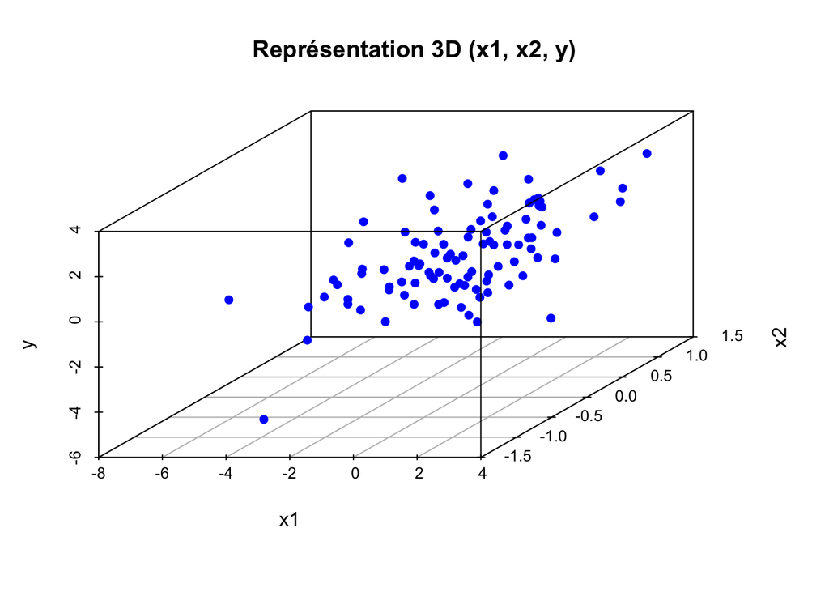

```r
set.seed(2024)
x1 <- rnorm(100,0, 2)
x2 <- rnorm(100,0, 0.5)
a <- 0.2  # small but not negligible effect
b <- 1.5  # stronger effect
y <-a* x1 + b*x2 +rnorm(100)

scatterplot3d(x1, x2, y, pch = 16, color = "blue", main = "Représentation 3D (x1, x2, y)",
             xlab = "x1", ylab = "x2", zlab = "y")
```

Lasso is ideal in high-dimensional settings where many predictors may have little to no effect, allowing for a more interpretable and sparse model.

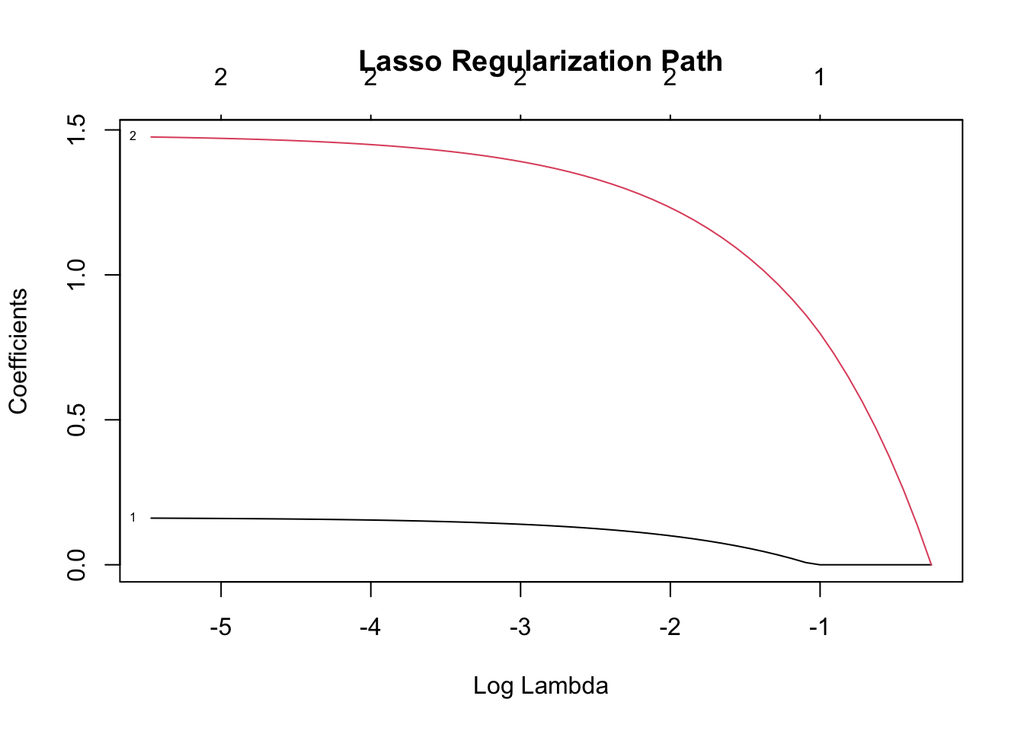

```r
library(glmnet)
set.seed(2024)
x<-cbind(x1,x2)
fit.lasso=glmnet(x,y,alpha=1)
plot(fit.lasso, xvar="lambda", label=TRUE, main='Lasso Regularization Path')
```

📈 The Lasso estimator not only shrinks the coefficients but also performs **variable selection** by setting some coefficients to **zero**. This results in a **sparse model** where only the most important predictors are retained, facilitating interpretability. While the Ridge regression keeps all variables in the model, Lasso helps in reducing model complexity by excluding some predictors, which improves interpretability and reduces overfitting when dealing with high-dimensional data.

# 3. Elastic-Net regression

## 3.1. Définition

**[Elastic-Net estimator]**

Let $\lambda_1>0$ and $\lambda_2>0$, the Elastic-Net estimator (introduced [Zou & Hastie]) denoted by $\widehat\beta^{EN}(\lambda_1,\lambda_2)$ is defined as follows
$$\widehat\beta^{EN}(\lambda_1,\lambda_2)=\arg\min_{\beta\in\mathbb{R}^p}\|Y-X\beta\|^2+\lambda_1\|\beta\|_1+\lambda_2\|\beta\|_2^2.$$
Let $\lambda>0$, the Elastic-Net estimator can also be defined as follows
$$\widehat\beta^{EN}(\lambda,\alpha)=\arg\min_{\beta\in\mathbb{R}^p}\|Y-X\beta\|^2+\lambda\left(\alpha\|\beta\|_1+(1-\alpha)\|\beta\|_2^2\right),$$
where $\alpha\in[0,1]$.

The parameter $\lambda$ is called the **regularization parameter** and the parameter $\alpha$ is the **mixing parameter**.

📝 **No Closed Form Solution.** Similar to the LASSO, the Elastic-Net does not have a closed form solution. However, it poses a convex optimization problem, allowing for efficient approximation algorithms.  
📝 **Combination of Methods.** The Elastic-Net regression combines features from both Ridge regression and LASSO regression, leveraging the strengths of both methods.  
📝 **Regularization Effects.** *Ridge method* prevents overfitting by shrinking the coefficients but does not perform variable selection; all regressors remain in the model. In contrast, *LASSO method* also shrinks coefficients but can set some to zero, effectively facilitating feature selection.  
📝 **Hyperparameter Calibration.** Just like in Ridge and LASSO, the hyperparameters $\lambda$ and $\alpha$ in the Elastic-Net must be properly calibrated to achieve optimal performance.

📌 **Lack of Testing Theory.** As with Ridge and LASSO regressions, there is currently no established theory for hypothesis testing and confidence intervals specific to Elastic-Net regression. However, it is important to note that bootstrapping methods exist to construct confidence intervals, providing some means of statistical inference ([Bertin and Vignoles]). Additionally, there are asymptotic results ([Zou and Hastie], [Li and Zhang] ) available under certain conditions that facilitate inference, although these may not be as well-developed or universally applicable as those for LASSO or Ridge regression.

## 3.2. Different Libraries

**1. Function `enet` from the `elasticnet` package**

- This function is used to perform Elastic-Net regression, combining both Lasso and Ridge penalties, controlled by the `lambda` parameter.

```r
library(elasticnet)
model <- enet(x.train, y.train, lambda = lambda_value, intercept = FALSE)
```

- *Standardization*: **By default**, `enet` **does not standardize** the regressors or the response variable. To standardize your data before fitting the model, you must do this manually:

```r
x.train_scaled <- scale(x.train)
y.train_scaled <- scale(y.train)
model <- enet(x.train_scaled, y.train_scaled, lambda = lambda_value, intercept = FALSE)
```

- *Intercept*: To include an intercept in the model, set `intercept = TRUE`.

**2. Function `train( , method='glmnet', alpha=0.5)` from the `caret` package**

- The `train()` function in the `caret` package can be used to train Elastic-Net models. Set `alpha` between 0 and 1 to control the mixing parameter, with `alpha=0.5` representing an equal mix of both penalties.

```r
library(caret)
model <- train(x.train, y.train, method = 'glmnet', tuneGrid = expand.grid(alpha = 0.5, lambda = lambda_value))
```

**3. Function `glmnet()` from the `glmnet` package**

- The `glmnet()` function can be utilized for Elastic-Net regression by setting `alpha` between 0 and 1, where `alpha=0.5` indicates an equal contribution from both penalties.

```r
library(glmnet)
model <- glmnet(x.train, y.train, standardize = TRUE, alpha = 0.5, lambda = lambda_value)
```

- *Standardization of the regressors*: By default, `glmnet` **automatically standardizes the regressors**. If you prefer not to standardize, set `standardize = FALSE`.
- *Standardization of the response variable*: The response variable is **not standardized** by default. If necessary, manually scale it before passing it to the `glmnet` function:

```r
y.train_scaled <- scale(y.train)
model <- glmnet(x.train, y.train_scaled, standardize = TRUE, alpha = 0.5, lambda = lambda_value)
```

## 3.3. Toy example

**Ⓡ** **Toy Examples with Elastic-Net.** In this example, we simulate a scenario with multiple predictors to illustrate the power of Elastic-Net for both regularization and variable selection.

We will create a dataset where several predictors are weak, while a few have significant effects on the response variable. Moreover, the first two predictors $X_1$ and $X_2$ are highly correlated. This setup demonstrates how Elastic Net can effectively handle situations with multicollinearity while performing variable selection. .

```r
set.seed(2024)
n <- 200
p <- 10
x <- matrix(rnorm(n * p), nrow = n, ncol = p)
x[, 2] <- x[, 1] + rnorm(n, sd = 0.75)  # Introduce correlation between x1 and x2
correlation <-cor(x[, 1], x[, 2])
cat("Correlation=",correlation)
```

```
## Correlation= 0.8158672
```

Create a response variable with only a few predictors having significant effects. Here, only first two predictors are significant

```r
true_coefficients <- c(2, -1, 0, 0, 0, 0, 0, 0, 0, 0)
y <- x %*% true_coefficients + rnorm(n, sd = 0.5)
```

Visualize the relationship

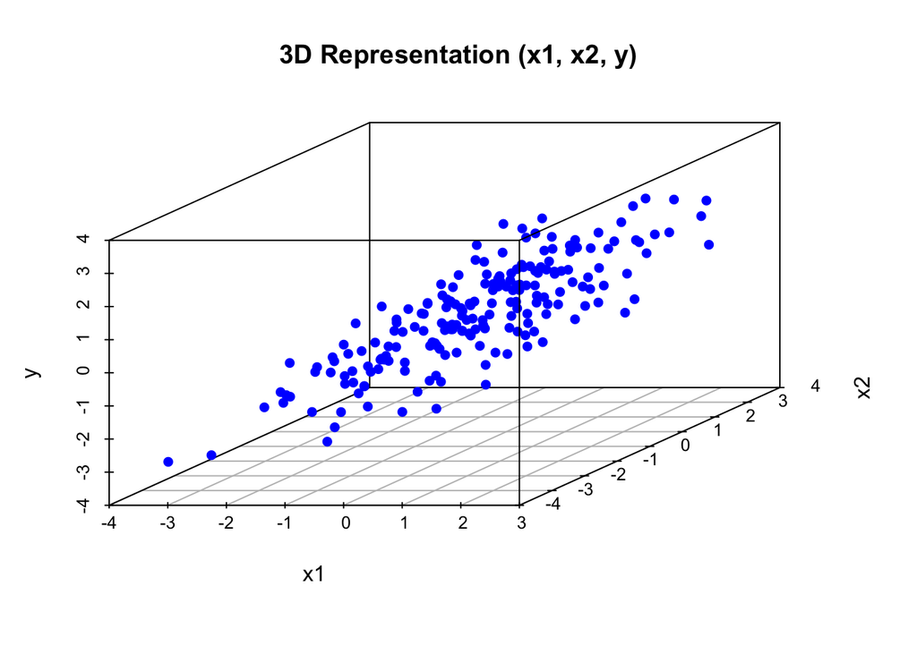

```r
library(scatterplot3d)
scatterplot3d(x[, 1], x[, 2], y, pch = 16, color = "blue", main = "3D Representation (x1, x2, y)",
               xlab = "x1", ylab = "x2", zlab = "y")
```

This setup highlights the scenario where Elastic-Net is particularly beneficial.

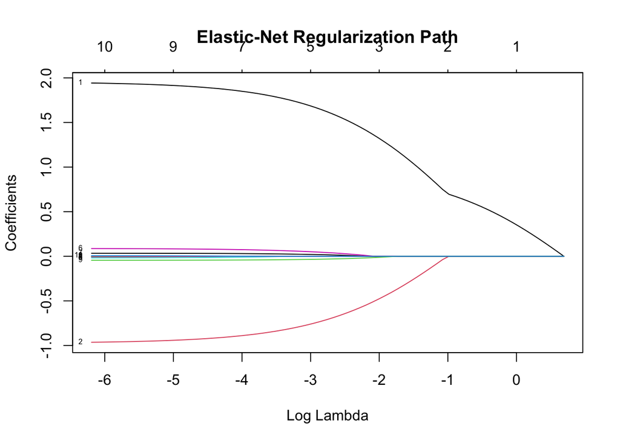

```r
library(glmnet)
fit.elasticnet = glmnet(x, y, alpha = 0.5)  # Elastic-Net with alpha = 0.5
plot(fit.elasticnet, xvar = "lambda", label = TRUE, main = 'Elastic-Net Regularization Path')
```

📈 The Elastic-Net estimator not only shrinks coefficients but also performs **variable selection** by setting some coefficients to **zero** while retaining others. This results in a **sparse model** that highlights the most important predictors, facilitating interpretability. By leveraging both Lasso and Ridge penalties, Elastic-Net addresses the limitations of each approach, effectively balancing model complexity and predictive power in high-dimensional data contexts.

# 4. PLS regression (Partial least square)

## 4.1. Definition/Main result

The principle of Partial Least Squares (PLS) regression is conceptually similar to Principal Component Regression (PCR). The goal of PLS is to construct new latent variables or components, denoted by $t^{(1)},\cdots,t^{(k)}$, that have the following properties:

- Each component is a linear combination of the original predictors (which are assumed to be centered and standardized beforehand, such that $\overline{Y}=\overline{X}_j=0$ and $s^2_Y=s^2_{X_j}=1$).
- The components are mutually orthogonal: $\forall i\neq i'\quad\text{we have}\quad<t^{(i)} ,t^{(i')}>=0.$.
- The components are ranked by their relevance, with each component selected to maximize its correlation with the response variable $Y$, thereby capturing the most important predictive directions.

$\left\|\begin{array}{lll} \color{blue}{\text{PLS Algorithm : Step 1}}&&\\ {\large{\hookrightarrow}} \text{ Initialization:} & X^{(1)} = X \,\text{ and }\, Y^{(1)} = Y.& \\ {\large{\hookrightarrow}} \text{ First PLS Component:} & t^{(1)} = \underset{\substack{t=X^{(1)}w,\\ \|w\|^2=1}}{\text{arg max}}\langle t,Y^{(1)} \rangle. & \\ {\large{\hookrightarrow}}\text{ Regression of } Y^{(1)} \text{ on } t^{(1)}: & Y^{(1)} = r_1 t^{(1)} + \widehat\epsilon_1 \,\text{ and } \, r_1 t^{(1)} = P_{[t^{(1)}]} Y^{(1)}. \\ {\large{\hookrightarrow}}\text{ Coefficient Estimation:} & r_1 = (t^{(1)\,T} t^{(1)})^{-1} t^{(1)\,T} Y^{(1)}. & \\ {\large{\hookrightarrow}}\text{ Residual Calculation:} & \widehat\epsilon_1 = P_{[t^{(1)}]^{\perp}} Y^{(1)}. & \end{array}\right.$

Here, $r_1 \in \mathbb{R}$ represents the regression coefficient estimated using least squares, i.e., through the orthogonal projection onto $t^{(1)}$. The residual $\widehat{\epsilon}_1$ corresponds to the portion of $Y^{(1)}$ not explained by $t^{(1)}$.

Let generalize the process for any step $k$ in the Partial Least Squares (PLS) algorithm, continuing to add orthogonal components to the model.

- **Update**: The data matrix $X^{(k)}$ and the response $Y^{(k)}$ are updated by projecting them orthogonally to the previous PLS component $t^{(k-1)}$.
- **Component Calculation**: The next PLS component $t^{(k)}$ is computed by maximizing the correlation with the current updated response $Y^{(k)}$.
- **Regression**: The response $Y^{(k)}$ is regressed onto the new component $t^{(k)}$, resulting in a new coefficient $r_k$ and residual $\widehat{\epsilon}_k$.
- **Residual**: The new residual $\widehat{\epsilon}_k$ represents the part of $Y^{(k)}$ that is not explained by $t^{(k)}$.

$\left\| \begin{array}{lll} \color{blue}{\text{PLS Algorithm : Step k}} && \\ {\large{\hookrightarrow}} \text{ Update:} & X^{(k)} = P_{[t^{(k-1)}]^{\perp}} X^{(k-1)} \text{ and } Y^{(k)} = P_{[t^{(k-1)}]^{\perp}} Y^{(k-1)} = \widehat\epsilon_{k-1}. & \\ {\large{\hookrightarrow}} \text{ Compute the k-th PLS Component:} & t^{(k)} = \underset{\substack{t=X^{(k)} w,\\ \|w\|^2=1}}{\text{arg max}} \langle t, Y^{(k)} \rangle. & \\ {\large{\hookrightarrow}} \text{ Regression of } Y^{(k)} \text{ on } t^{(k)}: & Y^{(k)} = r_k t^{(k)} + \widehat\epsilon_k \text{ and } r_k t^{(k)} = P_{[t^{(k)}]} Y^{(k)}.& \\ {\large{\hookrightarrow}} \text{ Coefficient Estimation:} & r_k = (t^{(k)\,T} t^{(k)})^{-1} t^{(k)\,T} Y^{(k)}. & \\ {\large{\hookrightarrow}} \text{ Residual Calculation:} & \widehat\epsilon_k = P_{[t^{(k)}]^{\perp}} Y^{(k)}. & \end{array} \right.$

📝 **Orthogonality of PLS Components.** By construction, the PLS components $t^{(j)}$ are orthogonal to each other. This is due to the fact that each subsequent data matrix $X^{(j)}$ is obtained by projecting the previous data matrix $X^{(j-1)} $ orthogonally onto the complement of the previous component $t^{(j-1)}$, i.e.,
$$X^{(j)} = P_{[t^{(j-1)}]^{\perp}} X^{(j-1)}.$$
Therefore, $X^{(j)} \in \text{span}(t^{(1)}, \cdots, t^{(j-1)})$, and as a result, $t^{(j)}$ is orthogonal to all previous components $t^{(1)}, \cdots, t^{(j-1)}$.

📝 **Maximizing Empirical Correlation with $Y$.** Each PLS component $t^{(j)}$ is chosen to maximize its empirical correlation with the response variable $Y$, which has been centered along with the predictor variables in $X$. This ensures that each new component captures the maximal amount of information related to $Y$, while maintaining orthogonality to previous components.

📝 **Hyperparameter Calibration.** As in other regression techniques, the number of PLS components $k$ is a crucial hyperparameter that must be carefully calibrated to avoid underfitting or overfitting the model.

**[Theorem 3]**

The PLS model is written as follows :
$$\begin{eqnarray*}
Y&=&
P_{[t^{(1)}]}Y^{(1)}+\cdots+P_{[t^{(k)}]}Y^{(k)}+\widehat\epsilon_k\\
&=& r_1t^{(1)}+\cdots+r_kt^{(k)}+\widehat\epsilon_k,
\end{eqnarray*}$$
where $\widehat\epsilon_k=P_{[t^{(k}]^{\perp}}Y^{(k)}=P_{{\rm span} (t^{(1)},\cdot,t^{(j-1)})}Y$.

*Proof.* Let in exercice.

## 4.2. Different Libraries

**1. Function `plsr()` from the `pls` package**

- The `plsr()` function is used to perform Partial Least Squares (PLS) regression. It allows you to estimate regression models when predictors are highly collinear or when the number of predictors exceeds the number of observations.

```r
library(pls)
model <- plsr(Y ~ X, data = train_data, ncomp = 5, validation = "CV")
```

- *Standardization*: By default, the `plsr` function **standardizes the regressors and the response**. If you do not want to standardize the variables, set `scale = FALSE`.

```r
model <- plsr(Y ~ X, data = train_data, ncomp = 5, scale = FALSE, validation = "CV")
```

- *Cross-Validation*: You can specify cross-validation using the `validation` parameter, as shown above (`"CV"` for cross-validation).

**2. Function `train( , method='pls')` from the `caret` package**

- The `train()` function from the `caret` package can also be used for PLS regression by specifying `method='pls'`. You can tune the number of components using the `ncomp` parameter.

```r
library(caret)
model <- train(X, Y, method = 'pls', tuneGrid = expand.grid(ncomp = 5))
```

**3. Function `plsda()` from the `mixOmics` package**

- The `plsda()` function from the `mixOmics` package is useful for PLS regression when performing classification (PLS-DA). For standard PLS regression, the `pls()` function can be used. Both allow the tuning of the number of components.

```r
library(mixOmics)
model <- pls(X, Y, ncomp = 5)
```

- *Standardization*: The `pls()` function **automatically standardizes the regressors** by default. To disable this behavior, set `scale = FALSE`.

```r
model <- pls(X, Y, ncomp = 5, scale = FALSE)
```

## 4.3. Toy Example

**Ⓡ** **Toy Example with PLS.** In this example, we will illustrate the effectiveness of PLS regression, especially when the predictors are highly correlated, similar to the Elastic Net case.

First, simulate a dataset where several predictors are highly correlated:

```r
set.seed(2024)
n <- 200
p <- 10
x <- matrix(rnorm(n * p), nrow = n, ncol = p)
x[, 2] <- x[, 1] + rnorm(n, sd = 0.75)  # Correlation between x1 and x2
correlation <-cor(x[, 1], x[, 2])
cat("Correlation=", correlation)
```

```
## Correlation= 0.8158672
```

Create a response variable where only a few predictors have significant effects. In this case, only the first two predictors are significant:

```r
true_coefficients <- c(2, -1, 0, 0, 0, 0, 0, 0, 0, 0)
y <- x %*% true_coefficients + rnorm(n, sd = 0.5)
```

Visualize the relationship:

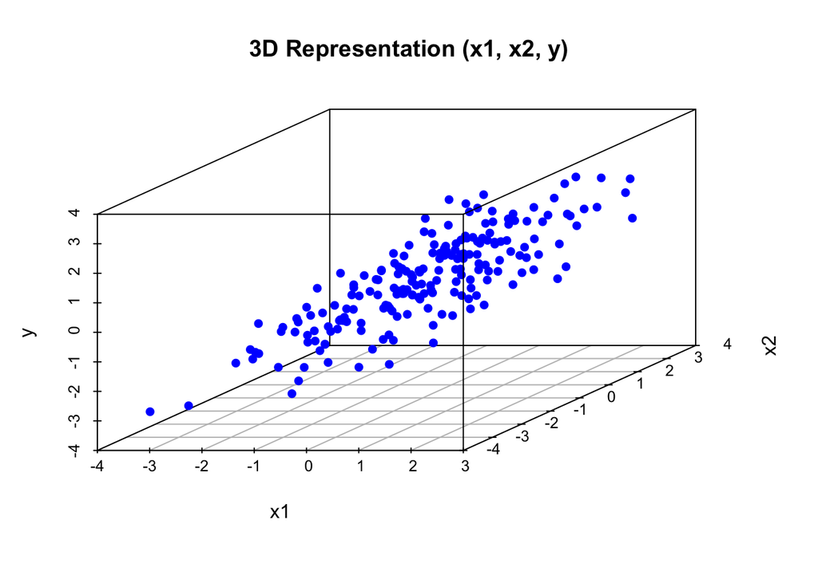

```r
library(scatterplot3d)
scatterplot3d(x[, 1], x[, 2], y, pch = 16, color = "blue", main = "3D Representation (x1, x2, y)",
               xlab = "x1", ylab = "x2", zlab = "y")
```

Now, Fit the PLS model with 10 components (or adjust as needed)

```r
library(pls)
set.seed(2024)
fit.pls <- plsr(y ~ x, ncomp = 10, validation = "CV")
```

Extract the proportion of variance explained by each component and Create a plot to visualize the proportion of variance explained by each component.

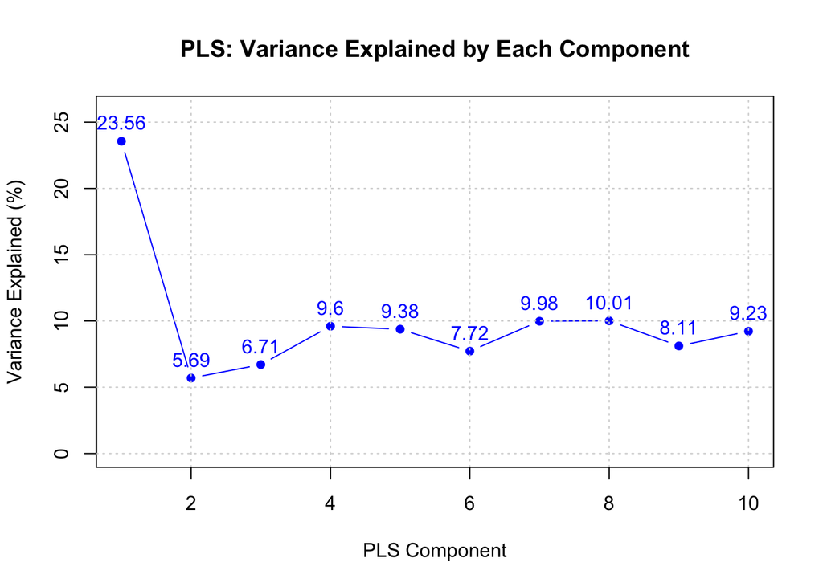

```r
explained_variance <- explvar(fit.pls)

plot(1:length(explained_variance), explained_variance, type = "b", pch = 16, col = "blue",
     xlab = "PLS Component", ylab = "Variance Explained (%)",
     main = "PLS: Variance Explained by Each Component",
     ylim = c(0, max(explained_variance) * 1.1))

grid()# Add gridlines for clarity

# Optional: Add percentage labels above each point
text(1:length(explained_variance), explained_variance,
     labels = round(explained_variance, 2), pos = 3, col = "blue")
```

📈 The PLS estimator effectively reduces the dimensionality of the model while accounting for multicollinearity. By introducing latent components, PLS can capture the variance shared between the predictors and the response variable, leading to a more interpretable and stable model in the presence of collinear variables.

# 5. Hyperparameter Tuning

## 5.1. Overview

When fitting a model and estimating $\widehat\beta$, relying on the entire dataset for training can lead to **overfitting**, meaning there’s no guarantee of good performance on new, unseen data. This emphasizes the **need for a properly partitioned dataset** to ensure robust model evaluation and tuning.

In cases where model fitting involves selecting hyperparameters (such as tuning $\lambda$ in regularization methods), **a proper dataset is even more crucial**.

**Ideally, we would use three datasets.**

- A **training set** to learn and compute the model estimates, $\{\widehat\beta_{\ell}(\lambda)\}_\lambda$, across different values of the hyperparameter.
- A **validation set** to assess and select the “optimal” hyperparameters, $\lambda_{\text{opt}}$, based on a predefined **evaluation criterion**. This helps identify the best model $\widehat\beta_{\ell}(\lambda_{\text{opt}})$.
- A **test set** to evaluate the final model’s predictive performance by computing a **performance score** for $\widehat\beta_{\text{train}}(\lambda_{\text{opt}})$ on unseen data.

**The Challenge.**

Splitting data into these three subsets is the ideal approach. However, in practice, datasets are often small, costly, or scarce. To address this, **cross-validation** can replace the validation set, allowing us to tune hyperparameters and assess model performance using the same training set while maximizing the available data for learning.

## 5.2. Holdout Method

In practice, we divide the original dataset $\{(x_i^T, y_i)\}_{i = 1, \ldots, n}$ into two subsets: the **training set** and the **test set**.

- A **training sample** of size $n_{\ell}$ is used for learning and model building, denoted as $(x^T_{\ell},y_{\ell})_{\ell}$. This subset is essential for estimating model parameters (and hyperparameters), such as $\widehat\beta_{\ell}$ (or $\widehat\beta_{\ell}(\lambda_{\text{opt}})$).
- An **independent test sample** of size $n_{t}$ is used to evaluate the model’s performance. This validation ensures that the estimated model generalizes well beyond the training data.

**Example.** One common metric for assessing performance on the test sample is the **Predicted Residual Error Sum of Squares (PRESS)**, calculated as:

$$\text{PRESS} = \|\widehat Y_{t} - Y_{t}\|^2 =
\|X_{t}\widehat\beta_{\ell} - Y_{t}\|^2 = \sum_{i=1}^{n_{t}}(\widehat
Y_{i} - Y_{i})^2,$$

where $\widehat\beta_{\ell}$ is the estimated parameter vector derived from the training sample.

📝 When dividing the dataset into two parts, a common proportion is $70\%$ for training and $30\%$ for testing.  
📝 For a three-way split, typical proportions are $60\%$ for training, $20\%$ for validation, and $20\%$ for testing.  
📝 Careful consideration should be given to the selection of subsets to ensure that each sample is representative of the overall dataset, thereby improving the reliability of the model evaluation.

## 5.3. Cross-Validation

Cross-validation is a powerful technique used for selecting the **optimal** hyperparameter(s) by evaluating model performance on the training data. Specifically, given an upper bound $\overline{\lambda}$ for the hyperparameter $\lambda$, the **optimal** $\lambda_{\text{opt}}$ is defined as the one that minimizes a specified criterion:

$$\lambda_{\text{opt}} = \arg\min_{\lambda \in [0, \overline{\lambda}]}
\text{Crit}(\lambda).$$

**$K$-Fold Cross-Validation**

In $K$-fold cross-validation, the training sample $(x_i^T, y_i)_{i = 1}^{n_{\text{train}}}$ is divided into $K$ equal sub-samples $(x_i^T, y_i)_{i = 1}^{n_{\ell_k}}$ of size $n_{\ell_k}$.

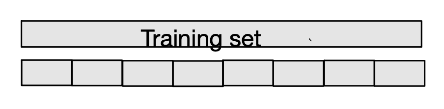

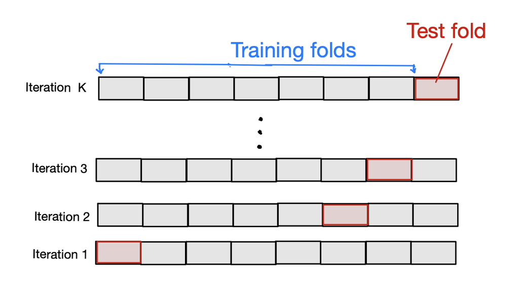

[*$K$-Fold Cross-Validation*]

**[PRESS]**

For each iteration $k$, the performance score is calculated using the **Predicted Residual Error Sum of Squares (PRESS)** for the $k$-th sub-sample:

$$\text{PRESS}^k(\lambda) = \|\widehat Y_{\ell_k}(\lambda) -
Y_{\ell_k}\|^2 = \|X_{\ell_k} \widehat\beta_{(-\ell_k)}(\lambda) -
Y_{t_v}\|^2,$$

where $\widehat Y_{\ell_k} = X_{\ell_k} \widehat\beta_{\ell}(\lambda)$ is the predicted response for the $k$-th sub-sample, and $\widehat\beta_{(-\ell_k)}(\lambda)$ is the estimated parameter vector calculated using the remaining $K-1$ folds.

Finally, the average PRESS across all $K$ folds is computed to estimate the overall prediction error:

$$\text{Crit}(\lambda) := \frac{1}{K} \sum_{k=1}^K \text{PRESS}^k(\lambda)
= \frac{1}{K} \sum_{k=1}^K \|X_{\ell_k}
\widehat\beta_{(-\ell_k)}(\lambda) - Y_{\ell_k}\|^2.$$

## 5.4. Leave-One-Out Cross-Validation (LOOCV)

In Leave-One-Out Cross-Validation (LOOCV), the number of folds $K$ is set to the total number of observations in the training dataset, $n_{\text{train}}$. This method involves training the model on $n_{\text{train}} - 1$ observations and validating it on the excluded observation. This process is repeated $n_{\text{train}}$ times, such that each observation serves as a validation point exactly once.

**[Cross-validation criterion]** The cross-validation criterion is defined as:

$$\text{Crit}(\lambda) := \text{PRESS}_{CV}(\lambda) =
\frac{1}{n_{\text{train}}} \sum_{i=1}^{n_{\text{train}}} \left(\widehat
Y_{i}(\lambda) - Y_{i}\right)^2 = \frac{1}{n_{\text{train}}}
\sum_{i=1}^{n_{\text{train}}} \left(x_i^T \widehat\beta_{(-i)}(\lambda)
- Y_{i}\right)^2,$$

where $\widehat\beta_{(-i)}(\lambda)$ is the parameter estimate obtained from the training set excluding the $i$-th observation $(x_i^T, Y_i)$.

📝 In the Ridge regression context, if we denote $H(\lambda) := X(X^TX + \lambda \mathbf{I}_p)^{-1}X^T$ as the projection matrix, we can express the prediction error for the $i$-th observation as:

$$x_i^T \widehat\beta_{(-i)}(\lambda) - Y_{i} = \frac{x_i^T
\widehat\beta(\lambda) - Y_{i}}{1 - H_{ii}} =
\frac{\widehat\epsilon_{i}(\lambda)}{1 - H_{ii}},$$

where $\widehat\beta(\lambda)$ is computed using the entire training sample, and $H_{ii}$ is the $i$-th diagonal element of the projection matrix $H$. Consequently, we can rewrite the PRESS criterion as:

$$\text{PRESS}_{CV}(\lambda) = \frac{1}{n_{\text{train}}}
\sum_{i=1}^{n_{\text{train}}}
\left(\frac{\widehat\epsilon_{i}(\lambda)}{1 -
H_{ii}(\lambda)}\right)^2.$$

📝 While LOOCV provides a very precise estimate of the optimal parameters, it can be computationally expensive due to the high number of model fits required. Therefore, **Generalized Cross-Validation (GCV)** is often preferred, where the term $1 - H_{ii}(\lambda)$ is replaced by $(1 - \text{Tr}(H(\lambda))/n)$, resulting in a more efficient calculation.

## 5.5. Generalized Cross-Validation (GCV)

In the context of Ridge regression, we calculate the parameter estimates $\left(\widehat\beta_t^R(\lambda)\right)_{\lambda}$ using the training sample $(X,Y)$ of size $n_{\text{train}}$:

$$\widehat\beta_\ell^R(\lambda) = (X^TX + \lambda \mathbf{I}_p)^{-1}X^TY,$$

and the predicted values are given by:

$$\widehat Y^R(\lambda) = H(\lambda)Y,$$

where $H(\lambda) = X(X^TX + \lambda \mathbf{I}_p)^{-1}X^T$ is the projection matrix for the Ridge regression model.

**[Generalized Cross-Validation criterion]** The Generalized Cross-Validation criterion is defined as:
$$\text{GCV}(\lambda) := \frac{\| Y - \widehat Y^R(\lambda) \|^2 /
n_{\text{train}}}{\left(\text{Tr}(\mathbf{I}_n - H(\lambda)) /
n_{\text{train}}\right)^2} = \frac{1}{n_{\text{train}}}
\sum_{i=1}^{n_{\text{train}}} \left(\frac{Y_{i} - \widehat
Y^R_{i}(\lambda)}{1 - \text{Tr}(H(\lambda))/n_{\text{train}}}\right)^2.$$

📝 This criterion effectively accounts for the bias introduced by estimating the parameters, providing a more reliable estimate of the prediction error while requiring significantly less computational effort than LOOCV. The GCV approach allows for efficient hyperparameter tuning without sacrificing model accuracy, making it a preferred choice in practice.

# Bibliography

[Bickel *et al*] Bickel, Ritov and Tsybakov, *Simultaneous analysis of LASSO and Dantzig selector* (2009, AOS).

[Zou and Hastie] Zou, H., & Hastie, T. (2005). *Regularization and variable selection via the elastic net*. Journal of the Royal Statistical Society: Series B (Statistical Methodology), 67(2), 301-320

[Li and Zhang] Li, R., & Zhang, Z. (2010). *The elastic-net regularization for high-dimensional data: Asymptotic properties*. Statistical Science, 25(1), 87-106.

[Bertin and Vignoles] Bertin, M., & Vignoles, V. (2021). *Bootstrap confidence intervals for the elastic net estimator*. Journal of Statistical Computation and Simulation, 91(8), 1647-1665.